Skip to main content

# Building a Secure Document Viewer

From first line of Java to production

Claude (Anthropic)

First edition, version 1.0

# About this edition

**Building a Secure Document Viewer: From First Line of Java to Production**

| Item | Detail |
| --- | --- |
| Author | Claude (Anthropic) |
| Edition | First edition, version 1.0 |
| Copyright and license | Text and figures: copyright 2026, all rights reserved. The code listings are excerpts of the Secure Document Viewer source code, which is released under the MIT License (the `LICENSE` file in the repo… |
| Code version | The repository tag `book-m6-final`; earlier milestones use the tags `book-m0-mvp` to `book-m5-platform` |
| Software versions | Java 25, Spring Boot 4.1.1, Spring Security 7, MySQL 8.4, Node 24, Angular 22, TypeScript 6.0, Docker Compose, Maven 3.9.16 (the first five milestones used Spring Boot 3.3.4 and Java 21) |
| Language | American English |

## What this edition is

This edition teaches you to build the Secure Document Viewer, a web application that shows PDF documents without handing out the PDF, and to understand every decision behind it. Every listing that is presented as the project's code is copied from the repository at the tag named in its caption; code written only to teach is labeled as an example, and sketches of things the project never built are labeled illustrative.

Part VII is a design study. The project never built or ran the application on a cloud platform, and the chapters say so.

## How the book was made

The author is Claude, an AI model made by Anthropic. The book and the application were written together with the project owner, who directed the work and reviewed it, and with further AI agents that helped research, write, review, and check the chapters. The Acknowledgments in the preface say more.

## Accessibility

The book is published as a PDF, an EPUB, and a single web page. All three contain real text, and every diagram has alternative text and a text description in the body. In the EPUB and web editions the difficulty stars on the exercises are labeled in words, and, in the web edition, code listings can be reached and scrolled with the keyboard. In the PDF the stars are shown only as symbols, and the meaning of one, two, and three stars is explained in How to use this book.

What was checked, on September 20, 2026: the PDF is a tagged PDF and passes the PDF/UA-2 check of veraPDF 1.30.2. The EPUB passes epubcheck, and Ace by DAISY 1.4.6 reports no failures for it. The web page passes the Nu HTML Checker 26.9.16 without errors. axe-core 4.13.0 reported no violations on 26 chapters of the EPUB and on a sample of the web page, Lighthouse 13.5.0 scored the sample 100 out of 100, and pa11y 10.0.0, run on 11 chapters and the sample, found no missing alternative text, heading, language, or table problems. Some color-contrast checks on code listings and star symbols could not be decided by these tools and were measured by hand instead; the checked code colors are at least 4.5 to 1 against their background. These tools were run on part of the book, not the whole book. The PDF does not pass PDF/UA-1.

What was not checked: nobody has tested these editions with a screen reader or other assistive technology, the PDF has not been checked with PAC or with the accessibility checker in Acrobat, and no third-party audit has been made. This book does not claim conformance with WCAG, PDF/UA, or EPUB Accessibility.

If you find a barrier, see Corrections and updates below: this edition is a frozen snapshot, so the way to fix a barrier is to fork the repository and correct it there.

## Corrections and updates

Software changes. Versions, screens, and documentation pages described here were checked on September 20, 2026. Where a chapter cites documentation, check the current page before you rely on a detail. This edition is a frozen snapshot: the repository is archived and read-only, so it does not take issues or pull requests. If you find an error, fork the repository and correct it there.

# Preface

This book teaches you to build a real application from your first line of Java. You need no programming experience. You need patience, a computer you can install software on, and curiosity about how things work.

Most programming books teach a language and then leave you to work out what to do with it. This one works the other way around. It starts from one concrete program, the **Secure Document Viewer**, and teaches exactly the tools that program needs, at the moment it needs them. When you finish, you will have built the application in the accompanying repository and you will understand why each decision in it was made, including the ones that were made after something went wrong.

## What you will build

The Secure Document Viewer is a web application that shows PDF documents to signed-in people without ever handing out the PDF. The server turns each page into small image pieces called tiles, draws the viewer's identity on every piece, and delivers the pieces through short-lived signed links. It has accounts and roles, private and shared documents, an audit trail, a reader that works on a phone, and a set of protections against the ways people try to abuse it. It runs in Docker, sits behind an HTTPS frontend, and can be backed up and watched.

This is the pattern commercial e-magazine and flipbook readers use. The book explains it from the ground up, so that "signed URL," "session binding" and "rate limit" are ideas you can use on your next project and not only words in this one.

## Why a real project

A real project forces the questions a tutorial can skip. What happens when two people replace the same file at the same moment? Why does a sign-in form need a throttle, and why must counting the attempts be one indivisible step? Why does a database need numbered migrations? Why does the server answer "not found" when the honest answer is "not allowed"? In a tutorial these questions never come up. In a real application they come up in the first week of use, and the answers are where most of the learning is.

The project was built in stages, and the repository keeps a bookmark (a Git tag) at the end of each stage. Part IV walks through those stages in order, so you watch the design grow: from a one-page demo that signs anyone in with only a name, to an application that has survived several rounds of independent review. Along the way you meet the bugs and the review findings that shaped it. They are told as stories: the problem, how it was found, the fix, and the lesson.

## How the book is organized

- **Front matter** gets your machine ready.
- **Part I, Foundations,** teaches programming with Java, the command line, Maven, Git, how the web works, SQL, and Docker. No framework yet.
- **Part II, The backend,** builds the server side with Spring Boot: web endpoints, storing data, signing people in, defending against abuse, working with PDFs, and images, and testing.
- **Part III, The frontend,** builds the browser side with TypeScript and Angular, and shows how it talks to the backend and how it is tested.
- **Part IV, Building the Secure Document Viewer,** assembles the whole application in seven milestones, each ending with an updated architecture diagram and the decisions and challenges of that stage.
- **Part V, Production,** takes the finished app to a real host: security review, deployment and HTTPS, backups, metrics, and supply-chain hygiene.
- **Engineering trade-offs (Chapter 37)** weighs every major decision against the alternatives, including what an enterprise would do differently.
- **Part VI, Patterns,** names the design and architectural patterns the app already uses, so you leave with a vocabulary for your next project.
- **Part VII, Taking it to the cloud,** closes the main text with a design for running the app on Amazon Web Services. It is a design, not a deployment, and it says so.
- The **appendices** hold the glossary, the architecture blueprints side by side, solutions to the exercises, command cheat sheets, and troubleshooting, followed by an index of the terms defined in the chapters.

## What the app does not do

The app raises the cost of copying a document and makes leaks traceable. It cannot make content uncopyable, because anything shown on a screen can be photographed. The book keeps that honesty throughout. Being clear about what a design does not achieve is part of engineering it, and Chapter 37 puts every major decision next to its costs.

## The stack

Java 25, Spring Boot 4, MySQL 8.4, TypeScript, Angular 22, Node 24, Docker, and Git. You learn only what this app uses. Topics the app doesn't need are left out or mentioned in a sentence. Where an earlier milestone used older versions (the first five milestones were built with Spring Boot 3.3.4 and Java 21), the chapter says so.

## A note on how this project was made

The application was built with an AI coding assistant working alongside the project owner, and it was examined between milestones by two independent AI review agents: the AI product-owner reviewer and the AI technical-manager reviewer. The book later calls them the PO reviewer and the TM reviewer. It says so wherever it matters and never presents those reviewers as people. What matters for you is that the findings were real: each was demonstrated against the running application, and each led to a change you can read in the repository.

## A promise about honesty

Everything in this book that is presented as the project's code is copied from the repository at a named tag. Where a listing is shortened, its caption says so. Where the book simplifies an idea for a beginner, it says so and tells you which chapter gives the full picture. If you find a place where it doesn't, that is a defect in the book, not a gap in your understanding.

## Acknowledgments

This book stands on the work of the people who build and maintain open-source software and the documentation that comes with it. The Secure Document Viewer is made of their projects, and every chapter sends you back to their official documentation: OpenJDK and Java, Spring Boot, Spring Security and Spring Session, Hibernate, and Flyway, Apache Maven, Apache PDFBox, and Apache Tomcat, MySQL, Docker, Git, Node.js, npm, TypeScript, and Angular, Vitest, Playwright, and axe-core, Testcontainers, nginx, and Caddy, and, for the diagrams, Mermaid. Thank you to their maintainers and to everyone who writes and corrects their documentation.

The author of this book is Claude, an AI model made by Anthropic. The application was built, and the book was written, together with the project owner, who set the goals, made the product decisions and reviewed the work. The PO reviewer and the TM reviewer, both AI agents, examined the application between milestones, and further AI agents helped research, write, review and check the chapters. The author checked the claims in the book against the code and the official documentation, and the book says so wherever the difference between checked and unchecked matters. Readers who find an error are the last and most important reviewers, and their corrections are welcome.

# How to use this book

## Reading order

Read Parts I to III in order. Part IV assembles the app milestone by milestone and assumes what those parts taught. Part V takes the app to production, and Chapter 37 weighs the trade-offs. Part VI (Chapters 38 and 39) names the patterns you have been using, and Part VII (Chapters 40 and 41) sketches the next step: a cloud design that the project never deployed.

If you already know a topic, try its exercises first. If you can do the starred exercises without looking anything up, skim the chapter and move on. Each chapter's Prerequisites section lists the earlier chapters it assumes, and the table of contents lists the sections of every chapter.

Set up your machine (the next chapter of the front matter) before you start Chapter 1's exercises.

## Three tiers in every chapter

Each feature chapter has three tiers.

- The **Beginner tier** gives the core idea through an everyday analogy, defines the terms you need and explains the basic code line by line.
- The **Intermediate tier** shows how the pieces talk to each other, for example how the browser and the server exchange messages, and explains why this tool was chosen over the obvious alternatives.
- The **Advanced tier** covers security, performance, and architecture decisions, told through real incidents from this project.

On a first read you can stop after the beginner tier of each chapter and come back for the rest later. A later tier may use anything from the earlier tiers of the same chapter and from all earlier chapters; a beginner tier assumes only beginner material.

## Conventions

- **Bold** marks a term at its first use. The glossary (Appendix A) collects definitions of the terms, and the index at the end of the book lists, for each term, the chapters that use it, with the chapter that defines it in bold.
- Callouts come in four kinds: **Note** (useful, not essential), **Tip** (a habit that saves time), **Warning** (something that can lose data or break security) and **In this project** (where the idea lives in the repository).
- Listings are numbered by chapter, for example Listing 4.2. The caption names the file and the Git tag it was copied from. A shortened listing says "simplified" or "excerpt" and says what was left out. Code written only to teach is called an Example and carries no tag.
- Figures are diagrams written in text (Mermaid). Each has a caption and a one-sentence text description.
- Commands are shown without a prompt so you can copy them. They use `bash` syntax, which works in Git Bash on Windows, in Terminal on macOS, and in a Linux terminal. Where Windows PowerShell differs, both forms are given.
- Example names and addresses are fake, and passwords and secrets are always shown as placeholders in angle brackets. Never type a real password into a command you save.

## How to use the exercises

Every feature chapter ends with a *Try it* section of three to six exercises graded by stars.

- **One star** checks your understanding or asks for a small, guided change. Expect 5 to 15 minutes.
- **Two stars** applies the idea to a new case in the project, with some independence. Expect 30 to 60 minutes.
- **Three stars** asks you to extend, investigate, or design something, and may have more than one good answer. Expect an hour or more.

Work each exercise before you read its solution. When you get stuck, reread the section the exercise points to, then try a smaller version of the problem, then look at the hint. Solutions are in Appendix C, grouped by chapter. One-star and two-star exercises have full solutions. Three-star exercises have a worked outline and the key decisions ("one good answer is..."), because your own answer may be different and still right.

Exercises that change code ask you to work on a branch of your own, never on a tag directly. None of them needs anyone else's account, credentials, or deployment.

## Following along with the code

The repository has seven milestone tags, one for each chapter of Part IV. Table F.1 lists them.

Table F.1 — The milestone tags

| Tag | Milestone | Chapter |
| --- | --- | --- |
| `book-m0-mvp` | Tiled viewer with signed URLs and watermarks | 25 |
| `book-m1-accounts` | Accounts, roles, sessions, CSRF, sign-in throttling | 26 |
| `book-m2-documents` | Ownership, sharing, MySQL and Flyway, audit trail | 27 |
| `book-m3-hardening` | Upload and API hardening, secrets, operations | 28 |
| `book-m4-reading` | Reading experience, deep links, idle warning, watermark | 29 |
| `book-m5-platform` | Spring Boot 4, Docker, CI, production hardening | 30 |
| `book-m6-final` | The finished app | 31 |

A tag is a bookmark on a moment in the project's history. You can read a file exactly as it was at a tag without changing anything on your machine:

```bash
git show book-m2-documents:src/main/java/com/example/securedocviewer/document/DocumentService.java
```

To browse a whole tag, make a separate copy of the repository for reading and switch it to the tag there. Chapter 7 explains how, and why to keep your own work on a branch. Parts I to III use the final code (`book-m6-final`) for most examples, and each chapter says which tag its listings come from.

The first five tags were built with Spring Boot 3.3.4 and Java 21; the last two use Spring Boot 4.1.1 and Java 25. The book teaches the final stack, and each Part IV chapter tells you where the older versions differ.

## Getting stuck

Read the error message from its first line; most of the time it says what is wrong. Appendix E lists common setup and build problems with their causes and fixes. Appendix D is a command cheat sheet. Each chapter's Further reading points to the official documentation, which is the authority when the book and a tool disagree.

# Setting up your machine

You need six things: a terminal, Git, a JDK (Java Development Kit) 25, Node.js 24, Docker, and a code editor. This chapter walks through each on Windows, macOS, and Linux, and ends with a check that proves everything works. Installer pages change over time; where they differ from what is written here, follow the official page and use the version numbers below.

> **Note:** Installing takes 30 to 60 minutes, mostly downloads. You do this once.

Table S.1 — What you need and how to check it

| Tool | Version | Check command | You should see |
| --- | --- | --- | --- |
| Git | any recent | `git --version` | `git version 2.` and more |
| JDK | 25 | `java -version` | a line containing `25` |
| Node.js | 24 | `node --version` | `v24.` and more |
| npm | comes with Node | `npm --version` | a version number |
| Docker | recent | `docker --version` | `Docker version` and more |
| Docker Compose | v2 | `docker compose version` | `Docker Compose version v2.` |

## Step 1. Open a terminal

A **terminal** is a window where you type commands. Chapter 2 teaches it properly; for now you only need to open one.

- **Windows:** install Git (Step 2) first. It adds *Git Bash*; open it from the Start menu. This book's commands work there. Windows PowerShell also works for most commands.
- **macOS:** press `Cmd`+`Space`, type *Terminal*, press `Enter`.
- **Linux:** open your distribution's terminal application.

## Step 2. Git

**Windows:** download the installer from https://git-scm.com, run it, and accept the defaults.

**macOS:** run `git --version`. If Git is missing, macOS offers to install the developer tools; accept. Or install with Homebrew (`brew install git`).

**Linux:** use your package manager, for example `sudo apt install git` (Debian, Ubuntu) or `sudo dnf install git` (Fedora).

Check it:

```bash
git --version
```

Then tell Git who you are. This is stored on your machine and appears in your own commits; use any name and an address you don't mind showing.

```bash
git config --global user.name "Your Name"
git config --global user.email "you@example.com"
```

## Step 3. JDK 25

The JDK contains the Java compiler and the tools to run Java programs. Several vendors ship it; Eclipse Temurin is a common, free choice.

**Windows:** download the JDK 25 `.msi` installer from https://adoptium.net, run it, and enable the options that set `JAVA_HOME` and add Java to `PATH`.

**macOS:** download the JDK 25 `.pkg` from https://adoptium.net and run it, or use `brew install --cask temurin@25`.

**Linux:** install a JDK 25 package from your package manager if available, or unpack the Temurin archive and add its `bin` folder to your `PATH`.

Close and reopen your terminal (so it sees the new settings), then check:

```bash
java -version
javac -version
```

Both should report 25. If `java` reports an older version, another JDK comes earlier on your `PATH` (see Appendix E).

For the final code (`book-m6-final`) and for `book-m5-platform` you don't install Maven: the project's Maven wrapper (`./mvnw`) downloads the right version (3.9.16) the first time you use it.

> **Note:** The earlier milestones are different. The tags `book-m0-mvp` to `book-m4-reading` were built with Spring Boot 3.3.4 and **Java 21**, and they have no Maven wrapper, because `mvnw` first appears at `book-m5-platform`. To build and run one of those tags yourself, you need a JDK 21 and a Maven 3.9 that you install yourself. You don't have to: you can read those tags without building them, with `git show <tag>:<path>` (Chapter 7). Table IV.3 in the Part IV introduction lists what each tag needs.

**Optional: build the older tags (JDK 21 and Maven).** Skip this unless you want to run `book-m0-mvp` to `book-m4-reading` yourself. It keeps JDK 25 for everything else.

1. **Install JDK 21 next to JDK 25.** Use the same vendor as before (Eclipse Temurin, from the Adoptium project at https://adoptium.net) or your package manager's JDK 21. On macOS, `brew install --cask temurin@21`. On Linux, install your distribution's `openjdk-21` package or unpack the Temurin 21 archive in its own folder. Installing a second JDK does not remove the first.
2. **Install Maven 3.9.** Download the binary archive from the Apache Maven project (https://maven.apache.org/download.cgi), unpack it, and add its `bin` folder to your `PATH`. On macOS, `brew install maven` gives a current 3.9 release; on Linux, your package manager's Maven may be older than 3.9, so check the version in step 4 and use the archive if it is.
3. **Point one terminal at JDK 21.** Set `JAVA_HOME` to the JDK 21 folder and put its `bin` folder first on the `PATH`, only in the terminal window where you build an older tag. Replace the path with the folder your installer created.

   In bash (macOS, Linux, Git Bash on Windows):

   ```bash
   export JAVA_HOME="<path to your JDK 21 folder>"
   export PATH="$JAVA_HOME/bin:$PATH"
   ```

   On macOS you can find the folder with `/usr/libexec/java_home -v 21`.

   In Windows PowerShell:

   ```powershell
   $env:JAVA_HOME = "<path to your JDK 21 folder>"
   $env:Path = "$env:JAVA_HOME\bin;$env:Path"
   ```

   In Windows cmd:

   ```
   set JAVA_HOME=<path to your JDK 21 folder>
   set PATH=%JAVA_HOME%\bin;%PATH%
   ```

4. **Check it.** In that terminal:

   ```bash
   java -version
   mvn -version
   ```

   `java -version` should report 21, and `mvn -version` should report Maven 3.9 and Java 21. Close the terminal when you are done, and the next one uses JDK 25 again.

## Step 4. Node.js 24

Node.js runs JavaScript outside a browser, and npm (installed with it) downloads the libraries the Angular frontend needs.

**Windows and macOS:** download the Node 24 installer from https://nodejs.org and run it with the defaults.

**Linux:** use your package manager's Node 24 package, or a version manager such as `nvm` (`nvm install 24`).

Check it in a new terminal:

```bash
node --version
npm --version
```

## Step 5. Docker

Docker runs the MySQL database (and later the full application) in containers, so you don't install a database by hand.

**Windows and macOS:** install Docker Desktop from https://www.docker.com/products/docker-desktop and start it. Wait until it reports that it is running. On Windows it may ask you to enable WSL 2 or virtualization; follow its prompts and restart if asked.

**Linux:** install Docker Engine and the Compose plugin following https://docs.docker.com/engine/install/ for your distribution. To run `docker` without `sudo`, add yourself to the `docker` group and sign in to your computer again.

Check it, then run Docker's test container:

```bash
docker --version
docker compose version
docker run --rm hello-world
```

The last command should print a message beginning "Hello from Docker!".

> **Tip:** If `docker` says it cannot connect to the daemon, Docker Desktop isn't running yet. Start it and wait a minute.

## Step 6. An editor

Any code editor works. Two common free choices:

- **IntelliJ IDEA Community Edition** (https://www.jetbrains.com/idea/): strongest for Java.
- **Visual Studio Code** (https://code.visualstudio.com/): good for Java, TypeScript, and Markdown.

## Step 7. Get the code

Choose a folder that is **not** inside OneDrive, Dropbox, or another synced folder. Those services lock and rewrite files while the app is using them. For example, use `C:\dev` on Windows and `~/dev` on macOS and Linux.

```bash
mkdir -p ~/dev
cd ~/dev
git clone <repository-url> secure-doc-viewer
cd secure-doc-viewer
git tag
```

Replace `<repository-url>` with the address of the repository you were given. In Git Bash on Windows, if you prefer `C:\dev`, run `mkdir -p /c/dev && cd /c/dev` instead of the first two lines.

You should see the seven milestone tags:

```
book-m0-mvp
book-m1-accounts
book-m2-documents
book-m3-hardening
book-m4-reading
book-m5-platform
book-m6-final
```

Keep this clone for reading. When an exercise asks you to change code, make a branch of your own or a second clone (Chapter 7).

> **Warning:** Don't switch to a tag in a folder where you have unsaved work. Chapter 7 shows how to look at a tag safely.

## Step 8. The final check

Run these one after another. Each should print a version.

```bash
git --version
java -version
node --version
npm --version
docker --version
docker compose version
```

If all of them work, you're ready for Chapter 1. If one fails, see Appendix E. Chapter 3 runs your first Java program, and Chapter 10 starts the database.

## Further reading

- Git: https://git-scm.com/book
- Eclipse Temurin installation: https://adoptium.net/installation/
- Node.js downloads: https://nodejs.org/en/download
- Docker: https://docs.docker.com/get-started/

# Part I: Foundations

This part gives you the vocabulary and the tools you need to read and build the Secure Document Viewer. You start with no programming experience. By the end you can read most of the project's Java, follow its build, move around its history, explain how a browser talks to a server, read its database migrations, and start its database in a container.

Nothing in this part is theory for its own sake. Every chapter teaches a topic because the app uses it, and every chapter reaches into the real repository for its examples. When Chapter 3 teaches `if` statements, you read the rule that decides whether a password is acceptable. When Chapter 9 teaches indexes, you read the indexes the project added and why. The aim is that no line of the app looks like a foreign language when you meet it again in Parts II to V.

## What the part covers

Table I.1 lists the chapters and says why the app needs each topic.

Table I.1 — The chapters of Part I

| Chapter | Topic | Why the app needs it |
| --- | --- | --- |
| 1 | The big picture | The design, the three roles, and the app's honest limits |
| 2 | The command line and your files | Every tool in the book runs from a terminal, and the app's secrets live in environment variables |
| 3–5 | Java 25: values, control flow, classes, records, interfaces, collections, exceptions, time | The backend is written in Java |
| 6 | Maven and the project layout | Maven builds, tests, and packages the backend |
| 7 | Git and GitHub | The milestone tags are your checkpoints, and the history holds the project's story |
| 8 | How the web works | The browser and the backend speak HTTP and JSON, and cookies carry the sign-in |
| 9 | SQL and MySQL | Accounts, documents, and the audit trail live in a database |
| 10 | Containers and Docker | MySQL and the whole stack run in containers |

## Why this order

Each chapter uses only what earlier ones taught, with a small number of forward pointers that are marked as such. The command line comes first because every later step, from compiling to starting the database, is a command. Java comes next, because reading real code is the fastest way to learn, and Chapter 6 then explains how that code becomes a running program. Git and the web follow, and SQL and Docker come last because they build on the terminal and on the idea of a server.

Notice the rhythm: an idea, then a tiny teaching example you can run, then the same idea in the real code. Snippets labeled *Example* are small teaching code written for this book, and they carry no tag; you can type them into a scratch folder and run them. Snippets labeled *Listing* come from this repository at a named milestone tag, so you can print the exact same file with `git show <tag>:<path>` once Chapter 7 has taught you how.

## Before you start

You need a working setup: a terminal, Git, a JDK, Docker, and a code editor. The front matter has a step-by-step guide, Setting up your machine, with a check for each tool. Do it once now. You do not need Node.js yet; Part III asks for it. If a tool misbehaves later, the "Common mistakes" section at the end of each chapter lists the failures beginners hit most, with the symptom you will see and the fix.

Every chapter also ends with exercises graded ★, ★★ and ★★★, and each exercise has a worked solution in Appendix C. If you are short of time, do the ★ exercises in every chapter and the ★★ ones for chapters you found hard; the harder ones reward you when a later part builds on the same idea.

## If you already know some of this

Part I is written for a reader who has never programmed. If you have, skim what you know and slow down at the project-specific parts:

- Chapter 1 explains the design and its limits; read it whatever your background.
- Chapters 3 to 5 can be skimmed for Java syntax, but the incidents (a password limit measured in bytes, a sign-in race, audit times that came from the future) are worth reading.
- Chapter 6 shows the project's real `pom.xml`, including the reason for a pinned web-server version.
- Chapters 7 to 10 each contain a "real incident" from the project's history that later parts refer to.

## What you will have at the end

You will not have built the app yet. You will have a working machine, a small vocabulary that you have used on real snippets from this repository, and the confidence to read a file such as `DocumentController.java` without being lost. You will also have met the app's people (readers, publishers, and administrators), its five kinds of would-be attacker, and its seven milestones. Part II starts from there, with the backend.

# Chapter 1: The big picture

Before you write a line of code, you need a picture of what you're going to build and why it is built the way it is. This chapter describes the Secure Document Viewer in plain words, explains the one idea that shapes the whole design, and gives you a map of the tools the rest of the book teaches.

A word on how to use this book, since this is where you start. Follow along in a terminal: most chapters give commands to run against your own copy of the project, and Chapter 2 makes you comfortable with the command line. Do the exercises at the end of each chapter. They are graded ★ (5 to 15 minutes, checking your understanding), ★★ (30 to 60 minutes, applying the idea), and ★★★ (an hour or more, open-ended), and worked solutions are in Appendix C at the back of the book. When a chapter quotes code, it names the milestone tag, so you can read the same file with `git show <tag>:<path>` (Chapter 7 teaches this) and be sure you see exactly what the book saw. The front matter's "Setting up your machine" gets your tools ready. Finally, do not worry about remembering every new word in this chapter: the ideas return in later chapters, each time with more detail, and the book's glossary lists every term.

## Learning objectives

By the end of this chapter, you will be able to:

- Explain the problem the Secure Document Viewer solves, in one paragraph.
- Explain why hiding a download button in the browser does not protect a document.
- Describe how rasterizing a page and slicing it into tiles keeps the PDF on the server.
- Distinguish a client from a server and say which one you must trust less.
- Name the three roles and say what authentication and authorization mean.
- Follow one page view from sign-in to drawn tiles.
- Name the main tools in this book and say what each is for.
- State what the app cannot do, and match five threats to their defenses.

## Prerequisites

None. This chapter assumes only that you have used a web browser.

## Beginner tier: The problem and the idea

### 1.1 The problem: showing a document without giving it away

Imagine a company that sells a confidential report, a training manual, or a magazine. Customers must be able to read it on screen. The company would prefer that they can't email the file to a thousand strangers.

That is a tension, and it doesn't go away. To show a page on your screen, a computer has to send you something that draws that page. Whatever it sends, you can keep. So no design can make content uncopyable: a person can always photograph the screen.

The realistic goal is smaller and more useful:

1. Make casual copying inconvenient, so that the everyday paths (download the file, save the image) don't exist.
2. Make heavy copying slow, so that harvesting a whole document takes long enough to notice.
3. Make every copy traceable, so that a leaked image says who it was shown to.

The Secure Document Viewer is a small web application built to reach those three goals honestly. A signed-in reader opens a document in the browser and reads it page by page. The reader never receives the **PDF** (Portable Document Format) file. A PDF is the common format for fixed-layout documents such as reports and manuals.

### 1.2 Who uses the app: three roles

Before looking at how the app protects a document, meet the people it serves. The app calls them **roles**, and there are three. Example usernames throughout this book follow the project's own tests: `reader.one`, `pub.one`, and `outsider.one`.

- A **reader** can open the documents they have access to, and nothing else. `reader.one` is a reader.
- A **publisher** can do everything a reader can and can also upload documents, which makes them the owner of what they upload. `pub.one` is a publisher.
- An **administrator** can additionally manage accounts and sessions and read the audit trail. The role is called `ADMIN` in the code.

The code says the same thing in a comment on the `Role` type. Roles are cumulative in practice. Every signed-in user can read documents they have access to, publishers can also upload, and admins can additionally manage accounts, sessions, and the audit log. There is no public sign-up. An administrator creates every account, and the very first administrator is created automatically the first time the app starts on an empty database. Two more ideas belong here, because every later chapter uses them. **Authentication** means proving who you are, which is what signing in does. **Authorization** means deciding what you are allowed to do, which the app checks separately for every action. A person can be authenticated and still not authorized: `outsider.one` can sign in, and still cannot open a document that was never shared with them. Each document has an owner and a **visibility**: either `PRIVATE` (only the owner, administrators, and the users the owner shared it with) or `EVERYONE` (any signed-in user). For a document you may not see, the app answers "not found," as if it did not exist at all, so an outsider cannot even learn that it exists. Chapters 8 and 16 explain why.

### 1.3 Why hiding a button doesn't protect anything

The obvious way to build a "protected" viewer is to send the PDF to the browser, then use the browser to hide the download button and block the right-click menu. Call this the **naive viewer**.

Here is why it fails. Your browser is a program running on *your* computer, under *your* control. Every instruction the site sends it, including "hide this button," is a request that the browser happens to honor. A person who opens the browser's **developer tools** (DevTools, a panel built into every browser that lets you inspect and change the page you're viewing) can undo the hiding in seconds. Even without that, the PDF already arrived on their machine, so it sits in the browser's **cache** (the folder where a browser keeps copies of files it has downloaded) waiting to be copied.

The project's README puts it bluntly: both tricks "live entirely in the browser, so both are undone in about ten seconds with DevTools." The lesson is the most important idea in the whole book, and you'll meet it again in every part:

> Anything enforced only in the client can be bypassed. Real protection lives on the server.

The app does still block the right-click menu in its viewer (the part of the app you see in the browser, built with a tool called Angular; Part III teaches it). It does so knowingly, as a bit of friction for casual users, and it treats that as no protection at all.

### 1.4 The tile idea: rasterize, slice, deliver one piece at a time

If the PDF must never reach the browser, the server has to send something else. The design does this in three steps.

1. **Rasterize.** To **rasterize** a page means turning a page described by shapes and text (which is what a PDF contains) into a grid of colored dots, an image. The server renders each PDF page as an image at 150 DPI (dots per inch).
2. **Slice.** The server cuts each page image into square **tiles** of 512 by 512 pixels (a pixel is one dot of the image). Tiles at the right and bottom edges are cropped shorter.
3. **Deliver.** The server keeps only the tiles. The original PDF stops existing as something the app can serve. The browser asks for tiles one at a time and assembles them on screen.

A US letter page (8.5 by 11 inches) at 150 DPI is 1,275 by 1,650 pixels. Divided into 512-pixel squares, that is 3 columns by 4 rows: 12 tiles. The project's README says the same in its own words: "a letter page is ~12 tiles". Figure 1.1 shows the flow.

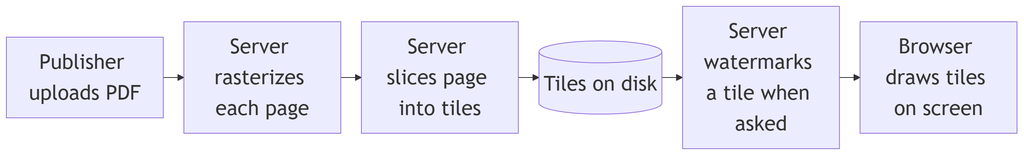

*Figure 1.1 — From PDF to tiles to screen*

*Text description:* Six boxes in a row, read left to right. A publisher uploads a PDF, the server turns each page into an image and cuts it into tiles, the tiles are stored on disk, and only when a tile is asked for does the server stamp a watermark on it before the browser draws it. Notice that the original PDF appears only at the start: nothing after the upload sends it to the browser.

Three more ingredients, explained in Section 1.8, make the tiles safe to serve: signed addresses, a watermark, and checks on every request.

### 1.5 Clients and servers, in one picture

Nearly everything on the web is a conversation between two kinds of programs.

- A **client** asks for things. Your browser is a client.
- A **server** listens for requests and answers them. It runs on a computer that stays on, and it holds the data.

Figure 1.2 shows one exchange in this app.

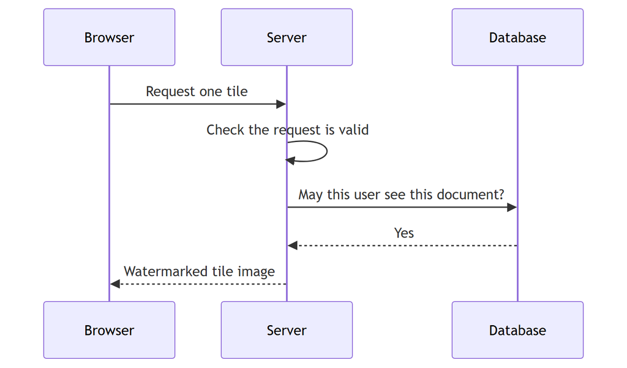

*Figure 1.2 — A browser asks for a tile*

*Text description:* A sequence of five messages between three parties, read top to bottom: Browser, Server, and Database. The browser asks for one tile, the server checks the request is valid, the server asks the database whether this user may see the document, the database answers yes, and the server returns a watermarked tile. Notice that the permission check goes to the database on every tile, not once per session.

The *Database* in the figure is a separate program that stores the app's accounts, documents, and permissions on disk so they survive a restart; Chapter 9 teaches it. Two rules follow, and the rest of the book depends on them:

- The client is under the user's control, so the server treats everything it sends as untrusted until checked.
- The server holds the secrets: the signing key, the tiles, and the database.

Chapter 8 teaches how the conversation works in detail (requests, status codes, cookies). For now, you only need the two roles.

### 1.6 The parts of the app and the tools you'll meet

The app has four moving parts, and this book has a part for each layer of tooling around them. The **backend** is the part that runs on a server and holds the data and the rules. The **frontend** is the part that runs in your browser and draws the pages you see. Table 1.1 is the map. Each tool in it is explained where the book teaches it, so treat the names as labels for now.

Table 1.1 — The parts of the app and the tools that build them

| Part of the app | What it does | Main tools | Where you learn it |
| --- | --- | --- | --- |
| Backend | Renders tiles, checks permissions, signs URLs, stores data | Java 25, Spring Boot 4, Maven | Chapters 3–6 and Part II |
| Database | Stores accounts, documents, shares, and the audit trail | MySQL 8.4, Flyway | Chapter 9 and Chapter 14 |
| Frontend | The pages you see in the browser | TypeScript, Angular 22, Node | Part III |
| Packaging and delivery | Runs everything the same way on any machine | Docker, Git, GitHub Actions | Chapters 7 and 10, Part V |

The source code is in this repository. You will follow it through seven checkpoints, one per milestone, marked with Git tags from `book-m0-mvp` to `book-m6-final`. Chapter 7 shows you how to look at any of them.

The path through the book is deliberate. Part I gives you the vocabulary: a language, a build tool, version control, the web, SQL, and containers. Parts II and III build the backend and the frontend. Part IV then rebuilds the app one milestone at a time, and Part V takes it to production.

### 1.7 What this app can and can't do

Being honest about limits is a design feature here, so learn them now.

**What it does:**

- The PDF stops being servable after upload; only disconnected tiles remain.
- Each tile address expires after 120 seconds by default and works only for the sign-in it was issued to (Section 1.8 explains how).
- Every tile carries the viewer's identity and a UTC timestamp (UTC is the world's reference time, with no daylight-saving changes).
- Each user is subject to a **rate limit**, a cap on how many requests one user may make in a period of time (here 180 tiles per 60 seconds by default), so a scripted harvest is slow.
- Every important action (sign-ins, uploads, views, denied requests) is written to the **audit trail**, an append-only record in the **database** (the program that stores the app's data permanently; Chapter 9 teaches it).

**What it does not do:**

- It does not make content uncopyable. Screenshots and photographs are not prevented.
- A determined user with a valid session can still request every tile and reassemble them. The rate limit bounds how fast, not whether. The README estimates about half an hour for a 500-page document at the defaults.
- It offers no multi-factor sign-in, which would ask for a second proof of identity, such as a code from a phone.
- Pages are images, so screen readers get no text. A screen reader is software that reads a page aloud for people who cannot see it.

The watermark is what makes a leak attributable. That is the honest promise: raise the cost, add attribution, and never claim prevention.

#### The numbers behind "slow"

"Slow" needs a number to mean anything, and the project chose its numbers deliberately. With 512-pixel tiles and a limit of 180 tile requests per minute, a reader can move through about 15 pages a minute (180 tiles divided by about 12 per page) without ever noticing the limit. A person copying a 500-page document with a script needs about 33 minutes. An earlier setting, 256-pixel tiles and 120 requests per minute, made a harvest take about 2.4 hours, but it also throttled ordinary reading: a reviewer found that a reader saw a blank page by about the fourth page. The project's owner accepted the current defaults and recorded the decision in the README, to be revisited from real usage. It is a good example of a trade-off in the open: protection against copying is bought with reading comfort, and someone decided how much to pay.

#### Why say all this so early?

A book that only showed the strengths of its project would teach you to overrate it. Security work depends on stating exactly what a defense does and does not achieve, so each later chapter repeats this habit: name the threat, name the defense, name what remains.

**Terms so far.** You have met the PDF, the three roles, authentication, and authorization, rasterizing and tiles, clients, and servers, the rate limit, the audit trail, and the database. The Intermediate tier adds URLs, signatures, sessions, and watermarks. If a term slips away, the glossary at the back of the book has it.

## Intermediate tier: Why it is built this way

*On a first read you can skim this tier; Parts II and IV return to every idea in it.*

### 1.8 Three more ingredients: signed addresses, watermarks, and checks

Rasterizing and slicing hide the PDF. Three more ingredients make the tiles safe to serve. Each gets its own chapter later; here is what each one is and why it exists.

**Signed, short-lived tile addresses.** A **URL** (Uniform Resource Locator) is a web address such as `https://example.com/page`. Every tile is fetched from its own URL, and that URL carries a **signature**: a short code that only the server can produce, computed from the rest of the address and a secret key. Change any part of the address and the signature no longer matches, so the server refuses it. The address also carries an expiry time. A URL like this is a **signed URL**. Chapter 17 explains signatures.

The address is also tied to one **session**. A session is the server's record that a particular browser has signed in: the browser proves who it is once, and the session saves it from sending the password with every request. An address issued to one session is refused for any other, so pasting it into another browser does not work.

**A per-viewer watermark.** A **watermark** is a faint mark laid over an image. When the server sends a tile, it stamps the viewer's username and a timestamp onto it, so every response is individually traceable.

**Access checks on every request.** The server verifies the sign-in and the document's permissions again for each tile, so unsharing a document cuts off a page that is already open.

#### An analogy, and where it breaks down

Think of a museum that will never lend you the painting. Instead it lets you look at the canvas through a window, one small square at a time, and the guard stamps your name on each square as you look.

**Where the analogy breaks down:** a museum guard can see you. The server can't; it only sees requests. Everything it knows about you comes from what your browser sends, which is why the server must check that information itself.

### 1.9 One page view, step by step

Put the pieces together by following one reader, `reader.one`, as they open page 3 of a document that was shared with them. Every step is a request from the browser to the server (Chapter 8 teaches the vocabulary), and the paths in this list are the app's real ones.

1. **Sign in.** The browser sends the username and password to `/api/auth/login`. The server checks them, starts a session, and answers with a **session cookie**: a small piece of text the browser stores and sends back with every later request, so the server knows which session it is.
2. **List the library.** The browser asks `/api/documents`. The server answers with only the documents this reader may open, not the whole library.
3. **Open a document.** The browser asks `/api/documents/{documentId}`, where `{documentId}` stands for the document's identifier. The answer describes each page: how many rows and columns of tiles it has, and how big each is. It contains no image and no link to a PDF.
4. **Ask for page 3's tile addresses.** The browser asks `/api/documents/{documentId}/pages/3/tile-urls`. The server checks permission again and answers with a grid of signed addresses of the form `/api/tiles?token=<signed-token>`, one per tile: 12 for a letter page.
5. **Fetch the tiles.** The browser requests each address. For every single one, the server checks four things in turn. First, the signature and expiry. Second, that the request comes from the very session the address was issued to. Third, that this reader has not exceeded the rate limit. Fourth, that the document is still shared with them. Only then does it stamp the watermark onto the tile and send it, marked so that no cache may keep it.
6. **Draw.** The browser places the 12 tiles side by side on the screen. The server records one "page viewed" entry in the audit trail, not one per tile.

Notice what never happens: at no step does the browser receive the PDF, and at no step does the server trust the browser's word about who it is. Each tile request is checked from scratch. That repeated checking is what lets an administrator cut off a reader instantly: end the session or unshare the document, and the next tile request fails. You will build each step in Part IV, one milestone at a time.

### 1.10 Why not something simpler?

Three simpler designs come to mind, and each fails in a way that teaches something.

- **Send the PDF with a viewer library.** The file is in the browser's memory and cache. Anyone can save it.
- **Send whole page images.** Better, but a single request returns a complete, high-quality page, and scripting that takes only a few lines. Tiles mean each individual response is a fragment.
- **Stamp one watermark at upload time.** Every reader would get an identical copy, so a leak would not say who leaked it. Stamping at request time costs processor time (CPU) on each request, and the README accepts that cost on purpose. Every one of these trade-offs is revisited in Chapter 37, which lists the enterprise alternative to each choice.

### 1.11 How this app came to be

The app you will build was not designed in one sitting, and its history is part of the teaching. Here is the outline, which Part IV tells in full.

The first version, milestone 0, was a backend only: rasterizing PDFs, slicing tiles, signed URLs, and the watermark, in a single first commit. Its own commit message states the rationale as serving PDFs without exposing the source file. An Angular frontend, an admin page, and an audit log followed. At that point the project's owner had two independent reviews done. Both reviewers were AI (artificial intelligence) review agents. A "product owner" reviewer looked at the reading experience, and a "senior technical manager" reviewer looked for engineering and security defects. Between them they listed 33 findings, 20 from the technical review and 13 from the product review. The most serious were startling for a security product. Any signed-in user could list every live session identifier (a session is the server's record of a sign-in; Section 1.8), and the identifier was the only credential, so any user could take over any other user's session. And sign-in accepted any username with no password at all. Both were fixed first, by giving the app real accounts (with passwords stored only as scrambled one-way hashes, Chapter 15) and by limiting who can see session information. The owner then approved a plan in five phases, with one pull request per phase. A pull request is a proposal to merge a set of changes into the main code, reviewed before it lands (Chapter 7). The five phases were real accounts and roles; ownership, sharing, a real database, and the audit trail; upload and error hardening; the reading experience; and finally the platform (Spring Boot 4, Java 25, Docker, automated checks). Those phases became milestones 1 to 5, and a few small maintenance changes became milestone 6. Each phase was checked with tests and by hand in a browser, and the fifth was reviewed in several more rounds before it was merged. By the last recorded count the project had 114 backend tests and 31 frontend tests. Two things follow for you as a reader. First, the code you will read has been through review, and many of its odd-looking details are scars from real findings; the book points them out. Second, you will see the app as it grew, so each concept arrives when the project first needed it, not all at once.

## Advanced tier: The mindset

*On a first read you can skip to "In this project"; Part V returns to threat thinking.*

### 1.12 Threat thinking

Security work starts by asking who might misuse the system and how. A **threat** is a specific way someone might misuse the system; a **defense** is what stands in the way. For this app, imagine five people. One is a curious reader who right-clicks. One is a reader who shares a tile URL in a chat. One is a scripter who requests every tile. One was never given access and guesses document identifiers. One steals a session. Table 1.2 sets each against the defense the app uses, and where you will learn it.

Table 1.2 — Five threats and the defense for each

| Who | What they try | The app's defense | Where taught |
| --- | --- | --- | --- |
| Curious reader | Save the image or the file | No file exists; right-click blocking is friction only | Chapters 1 and 21 |
| Sharer | Paste a tile URL into a chat | URL expires in 120 seconds and works only for its session | Chapters 8 and 17 |
| Scripter | Request every tile of every page | Per-user rate limit, watermark on every tile | Chapter 16 |
| Guesser | Try other document identifiers | Random identifiers, `404` for unseen documents, checks on every request | Chapters 9 and 16 |
| Session thief | Reuse someone's session identifier | Cookie hidden from scripts, identifiers never exposed, admin can end sessions | Chapters 15 and 16 |

Each of the app's protections answers one of them. You will see the answers as mechanisms in Parts II and IV, and you will test the strongest ones yourself. Chapter 32 turns this into a structured review. Notice that no row promises prevention: the defenses raise the cost, narrow the window, or make the act traceable.

### 1.13 Common misunderstandings

A few wrong ideas are worth clearing up now, because beginners meet them in the first week.

**"HTTPS protects the document from the reader."** HTTPS (the encrypted form of the web's request-and-response protocol; Chapter 8) protects data on its way between the server and the browser, so an eavesdropper on the network cannot read it. It does nothing about the reader, who is the intended recipient. The tile design addresses the reader; HTTPS addresses the wire.

**"A watermark stops leaks."** It does not. A watermark cannot stop a photograph. It makes a leaked image traceable to the account and time it came from, which changes people's behavior and gives an administrator something to investigate.

**"Signing in once means the server trusts me."** In this app the server re-checks identity and permission on every tile, because things change: an administrator may end your session, or the owner may unshare the document.

**"Authentication and authorization are the same thing."** They are not. The first is "who are you?", and the second is "what may you do?". A large share of real security bugs are missing or wrong authorization checks on someone who is properly signed in.

**"If the page hides it, it is protected."** The one lesson to keep from Section 1.3.

## In this project

At `book-m6-final`, the pieces from this chapter live in these places.

| Idea | Where |
| --- | --- |
| Tile size and DPI | `src/main/resources/application.yml` (`tile-size`, `render-dpi`) |
| Tile slicing math | `src/main/java/com/example/securedocviewer/service/TileGrid.java` |
| Signed tile URLs | `service/SignedUrlService.java` |
| Rate limit | `security/TileRateLimiter.java` |
| The frontend | `frontend/` |

You'll read these files in later chapters. You don't need to understand them yet.

## Try it

### Exercise 1.1 ★ Count the tiles

A page is 2,000 pixels wide and 3,000 pixels high, and tiles are 512 pixels square. How many columns and rows of tiles does it need, and how many tiles in total? Are the tiles at the edges full size?

*Hint:* divide, then round up.

*Solution:* Appendix C, Exercise 1.1.

### Exercise 1.2 ★ Client or server?

For each of these, say whether it can be enforced by the client, the server, or only the server: hiding the download button; checking that a tile URL has not expired; blocking a user who isn't allowed to see a document.

*Solution:* Appendix C, Exercise 1.2.

### Exercise 1.3 ★★ Read the limits

Read the "Limitations" section of `README.md` at `book-m6-final`. Pick two limits and, for each, write one sentence explaining why the design accepts it.

*Solution:* Appendix C, Exercise 1.3.

### Exercise 1.4 ★ Authentication or authorization?

For each, say whether it is authentication or authorization: the app checking your password; the app refusing to show you a document that was never shared with you; the app ending your session after 30 idle minutes.

*Solution:* Appendix C, Exercise 1.4.

### Exercise 1.5 ★★ Trace a page view

Using Section 1.9, list the requests a browser makes to show page 2 of a document whose pages are 3 columns by 4 rows, in order, and count the requests from the moment the reader has already signed in and opened the document. What would change if the document had a different tile size?

*Solution:* Appendix C, Exercise 1.5.

### Exercise 1.6 ★★★ Argue for a different trade-off

A customer says: "Our readers skim quickly; the rate limit gets in the way." A different customer says: "Our documents are extremely sensitive; slow the harvest more." Using Section 1.7, propose a different setting for each customer (tile size and requests per minute), estimate reading speed and harvest time for each, and say what you give up.

*Solution:* Appendix C, Exercise 1.6.

## Summary

- The app shows documents without ever serving the PDF: pages are rasterized, sliced into tiles and delivered one at a time.
- Protections that live only in the browser can be bypassed; real protection lives on the server.
- Signed short-lived URLs, per-viewer watermarks and per-request access checks each answer a specific misuse.
- The app raises the cost of copying and adds attribution. It does not, and cannot, prevent copying.
- There are three roles (reader, publisher, administrator); authentication proves who you are and authorization decides what you may do, and the app re-checks both on every tile request.
- One page view is a short chain of requests: sign in, list, open, ask for tile addresses, fetch each tile.
- "Slow" has numbers (about 15 pages a minute to read, about 33 minutes to harvest 500 pages), and the trade-off was decided in the open.
- The book teaches the tools in this order: language, build, version control, the web, SQL, containers.

## Further reading

- *MDN Web Docs*, "How the Web works." https://developer.mozilla.org/en-US/docs/Learn_web_development/Getting_started/Web_standards/How_the_Web_works
- *OWASP Foundation*, "Threat Modeling Cheat Sheet." https://cheatsheetseries.owasp.org/cheatsheets/Threat_Modeling_Cheat_Sheet.html

# Chapter 2: The command line and your files

Nearly every tool in this book is started by typing a command. This chapter teaches the small set of terminal skills you need: moving between folders, working with files, setting environment variables, and understanding what it means for a program to listen on a port. The app uses all of these. Its secrets live in environment variables, its settings come from files you edit, and its server listens on port 8080. By the end you will be able to type commands without fear and read the messages they print.

## Learning objectives

By the end of this chapter, you will be able to:

- Explain what a terminal and a shell are, and read the parts of a command.
- Move between folders and list their contents with commands.
- Create, read, copy, move, and delete files from the command line, and chain simple commands.
- Read and set an environment variable, and explain the `PATH`.
- Explain why the project keeps secrets in a `.env` file and how the app finds them.
- Explain what "listening on port 8080" means, and find what is using a port.
- Diagnose the common command-line errors.

## Prerequisites

- Chapter 1: The big picture

## Beginner tier: Talking to your computer in text

### 2.1 What a terminal and a shell are

Until now you have probably given your computer instructions by clicking. A **terminal** is a window where you type instructions instead. A **shell** is the program inside the terminal that reads what you type, runs it, and prints the result. The shell shows a **prompt**, a short line of text that says it is ready, often ending in `$`.

Why bother? Clicking cannot be written down and repeated. A command can be pasted into a document, run by a teammate, or run by a machine in the middle of the night. The project's build, its tests and its automated checks are all commands, and so is starting the database. When something goes wrong, a command and its output are also something you can copy into a bug report, which a description of clicks never is.

This book uses `bash` syntax. On macOS and Linux, open the Terminal app. On Windows, install Git for Windows, which includes **Git Bash**, and use that for every command in this book. (Windows also has PowerShell, whose syntax differs; where a PowerShell equivalent matters, the book shows it.)

**Analogy.** A terminal is like a phone call to a very literal assistant: you say exactly what you want, and it does exactly that.

**Where the analogy breaks down:** the assistant never asks "are you sure?". Commands such as delete run immediately and usually cannot be undone. It also breaks down in that a real assistant understands your intent, while the shell understands only the exact words and punctuation you typed.

#### Anatomy of a command

Every command has the same shape: the command name, then optional **flags** (also called options, which change how it behaves), then **arguments** (what to act on).

```bash
ls -l src
```

Here `ls` is the command, `-l` is a flag that asks for a long listing, and `src` is the argument, the folder to list. Flags start with one dash (short form, `-l`) or two (long form, `--help`). Words are separated by spaces, which is why a name that contains a space needs quotes: `cd "My Documents"`. Almost every command prints a summary of its flags if you add `--help`, for example `ls --help`.

### 2.2 Folders, paths, and moving around

Your files live in **folders** (also called directories) that nest inside each other. A **path** is the address of a file or folder. Paths use forward slashes in `bash`: `/c/dev/secure-doc-viewer` on Git Bash for Windows, or `/Users/you/dev/secure-doc-viewer` on macOS. Your path will differ. Git Bash shows the `C:` drive as `/c`.

The shell is always "in" one folder, called the **working directory**. Table 2.1 lists the commands you use to look around.

Table 2.1 — Navigation commands

| Command | What it does |
| --- | --- |
| `pwd` | Print the working directory |
| `ls` | List files in the working directory |
| `cd folder` | Move into `folder` |
| `cd ..` | Move up one level |
| `cd ~` | Move to your home folder |

A path is an **absolute path** if it starts from the top (`/c/dev/...`) and a **relative path** if it starts from where you are (`src/main`). The name `.` means "this folder" and `..` means "the folder above." Your **home folder** is where your personal files live, and `~` is shorthand for it.

Example 2.1 shows a short session. The lines starting with `#` are comments for you; the shell ignores them. If you have not cloned the project yet, use any folder; Chapter 7 shows how to get the project.

**Example 2.1 — Moving around**

```bash
pwd                      # where am I?
cd secure-doc-viewer     # go into the project folder
ls                       # what is here?
cd src/main/resources    # a relative path, three levels at once
cd ../../..              # back up three levels
```

Read the last line as "up, up, up." If you get lost, `cd ~` always takes you home and `pwd` always tells you where you are. Two habits will save you hours. Press `Tab` to complete a name, so you type `cd sec` and `Tab`. And press `↑` to bring back the previous command.

Figure 2.1 shows how the project's folders nest, using the top of the repository at `book-m6-final`.

```
secure-doc-viewer/
├── pom.xml
├── docker-compose.yml
├── .env.example
├── src/
│   ├── main/
│   │   ├── java/
│   │   └── resources/
│   └── test/
└── frontend/
```

*Figure 2.1 — The top of the project's folder tree (book-m6-final, abbreviated)*

*Text description:* An indented list showing the project folder at the top, with `pom.xml`, `docker-compose.yml` and `.env.example` directly inside it, then `src` (holding `main`, which holds `java` and `resources`, and `test`) and `frontend`. Notice that application code lives under `src/main` and tests live separately under `src/test`.

A folder inside another is written with slashes: `src/main/resources` is `resources` inside `main` inside `src`. The full layout gets its own section in Chapter 6.

### 2.3 Creating, reading, copying, and deleting files

Table 2.2 gives the essential file commands.

Table 2.2 — File commands

| Command | What it does |
| --- | --- |
| `mkdir notes` | Create a folder |
| `cat file.txt` | Print a file's contents |
| `cp a.txt b.txt` | Copy a file |
| `mv a.txt notes/` | Move (or rename) a file |
| `rm b.txt` | Delete a file, permanently |
| `rm -r notes` | Delete a folder and everything in it |

`rm` does not use a recycle bin. Read a delete command twice before pressing `Enter`. `rm -r` is the one to be most careful with, since it deletes a whole folder and everything inside it.

Practice in a folder that is not the project, so nothing you care about is at risk:

```bash
mkdir scratch
cd scratch
echo "Tiles are 512 px square." > tiles.txt
cat tiles.txt
cp tiles.txt tiles-backup.txt
mv tiles-backup.txt old.txt
ls
rm old.txt
```

`echo` prints the words after it, and the `>` sends that output into a file instead of the screen (creating it, or replacing it if it exists). `cat` prints the file. Then a copy, a rename with `mv` (moving a file to a new name is renaming it), a listing that should show `tiles.txt` and `old.txt`, and a delete.

#### Redirection and pipes

The `>` in the `echo` command is **redirection**: sending a command's output somewhere other than the screen. Two relatives are worth knowing. `>>` appends to a file instead of replacing it. And the **pipe** `|` feeds one command's output into another's input, so small tools combine into bigger ones:

```bash
cat tiles.txt | wc -w
```

`wc -w` counts words, so this prints the number of words in the file. A very common combination is `grep`, which prints only the lines that contain some text:

```bash
grep "512" tiles.txt
```

You will use `grep` to search the project: `grep -r "tile-size" src` searches every file under `src` (`-r` means recursive, into subfolders) for the text `tile-size`. When a command produces a screenful, add `| head` to see only the first ten lines.

### 2.4 Editing text files

You need one more tool: a **text editor**, a program for changing text files. Any plain-text editor works. Visual Studio Code is free and popular, and is what this book's screenshots and instructions assume where an editor matters. If you have it, `code .` in a terminal opens the current folder. The most important rule is to edit *text* files in a text editor and not in a word processor, which adds formatting the project's tools cannot read.

If you want to stay in the terminal, `nano notes.txt` opens a small editor whose commands are listed at the bottom of the screen; `Ctrl`+`O` saves and `Ctrl`+`X` exits.

## Intermediate tier: How programs find their settings

*On a first read you can skim this tier; every later chapter uses environment variables, and Chapter 10 returns to them.*

### 2.5 Environment variables and the PATH

An **environment variable** is a named value that the operating system (the software that manages your computer, such as Windows, macOS, or Linux) hands to every program it starts. You can set and read one in the shell:

**Example 2.2 — An environment variable**

```bash
export GREETING="hello"
echo $GREETING
```

The first line sets `GREETING`. The second prints its value; the dollar sign means "the value of the variable named." Variables set this way last only for that terminal window, and only programs started from that window can see them.

On Windows (PowerShell):

```powershell
$env:GREETING = "hello"
echo $env:GREETING
```

You can list every variable the shell holds with `env` (or `printenv`). The list is long; you did not set most of it. The system and the programs you installed put them there. To set a variable for one command only, put it in front:

```bash
GREETING=hello bash -c 'echo $GREETING'
```

That prints `hello`, and afterwards `GREETING` is unchanged, because the assignment lived only for that one command.

Why do programs use environment variables at all? Because settings such as a database address or a password change from one computer to another, and you do not want to edit and rebuild the program to change them. The same program runs on your laptop and in production, with different values in the environment.

One variable deserves special mention. `PATH` is a list of folders. When you type `java`, the shell searches each folder in `PATH`, in order, for a program with that name. If a tool "is not found" although you installed it, its folder is usually missing from `PATH`. You can see yours with `echo $PATH`, and ask where the shell found a program with `which java` (on Windows PowerShell, `Get-Command java`).

Figure 2.2 shows exactly how the shell decides what to run when you type a command such as `java -version`.

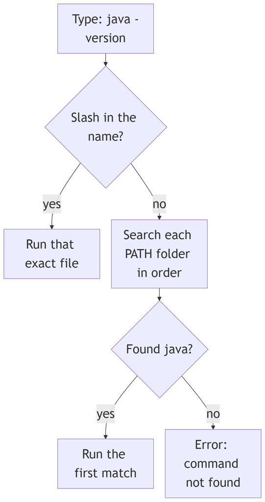

*Figure 2.2 — How the shell finds a program: a name with a slash skips PATH*

*Text description:* A decision flow read from top to bottom, starting with the typed command `java -version`. The shell first asks whether the name contains a slash, as in `./mvnw`. If it does, it runs that exact file. If it does not, it reads the `PATH` list, searches each folder in order, and runs the first program it finds, or reports "command not found" when the folders run out.

Notice the first decision. A name with a slash in it, like `./mvnw` (the Maven wrapper of Chapter 6), names one exact file, so the shell never consults `PATH`. That is why you type `./mvnw` and not `mvnw` alone: the current folder is not on `PATH`. A bare name like `java` triggers the search, in order, and the first match wins, which is why the order of folders in `PATH` matters when two versions of Java are installed.

A related variable is **JAVA_HOME**, which many tools (Maven among them, Chapter 6) read to find the folder where your JDK (Java Development Kit, Chapter 3) is installed. If a build complains about Java although `java -version` works, check `JAVA_HOME`.

### 2.6 Configuration through the environment: `.env` files

Typing `export` for a dozen variables every time you open a terminal would be tedious and error-prone. The project instead lists them in a file. Chapter 1 mentioned that the app needs secrets; here is the template that ships with it.

**Listing 2.1 — `.env.example` (book-m6-final, excerpt: the database block)**

```
# MySQL
DB_HOST=localhost
DB_PORT=3306
DB_NAME=securedocs
DB_USERNAME=securedocs
DB_PASSWORD=
DB_ROOT_PASSWORD=
```

*Path: `.env.example`*

Each line is `NAME=value`. The password lines are empty on purpose: you fill them in on your own machine, in a copy named `.env`. The other lines are safe defaults for local development. Copying the template is one command:

```bash
cp .env.example .env
```

Then open `.env` in a text editor and fill in the blanks with values you choose. Never paste a real password into a book, a chat, or a commit.

How does the app read this file? Its main settings file, `application.yml`, uses placeholders that mean "read this environment variable, or use this default":

**Listing 2.2 — `application.yml` (book-m6-final, excerpt: two settings)**

```yaml
spring:
  config:
    # Local development: secrets live in a git-ignored .env next to pom.xml
    # (the same file docker compose reads). Real environment variables win.
    import: optional:file:.env[.properties]

  datasource:
    # ...
    url: jdbc:mysql://${DB_HOST:localhost}:${DB_PORT:3306}/${DB_NAME:securedocs}?connectionTimeZone=UTC&forceConnectionTimeZoneToSession=true
```

*Path: `src/main/resources/application.yml`*

Read `${DB_HOST:localhost}` as "the value of `DB_HOST`, or `localhost` if it is not set". The `import` line tells the app to read a `.env` file if there is one (`optional:` means no error if it is missing), and the comment states the rule that matters: a real environment variable, if set, overrides the file. That precedence lets one machine, such as a production server, use environment variables and never have a `.env` file at all. **YAML** is a settings format where indentation shows nesting; Chapter 13 explains the whole file.

### 2.7 Text files, encodings, and line endings

A **text file** holds characters. Computers store everything as numbers called bytes, so an **encoding** is the rule that maps characters to bytes. The project's files use **UTF-8**, which stores plain English letters in one byte each and other characters, such as accented letters or emoji, in more. So a character is not always one byte, a fact that has a surprising consequence for passwords in Chapter 3.

A **line ending** marks where a line stops. Windows uses two bytes for it (a carriage return then a line feed, often written **CRLF**), while macOS and Linux use one (`LF`). Git and editors can convert between them, which matters in Chapter 7 and in Chapter 6, where a script with the wrong line endings fails with an error that mentions `\r`. The project's frontend includes an `.editorconfig` file that tells editors to save in UTF-8 and end each file with a newline, so every contributor's editor produces the same bytes. Now the reason for `.env` in one sentence. Secrets such as the database password and the key used to sign tile URLs must never be committed to version control. **Version control** is a tool that records every change to a project's files so that you can go back to any earlier state; Git is the one this project uses, and Chapter 7 teaches it. Its history is permanent and shared, so a secret committed once is exposed for good. So the project keeps a template, `.env.example`, in the repository, and asks you to copy it to `.env`. A file named `.gitignore` lists the files Git must not record, and it lists `.env`. The real values stay on your machine.

## Advanced tier: Ports, processes, and real incidents

*On a first read you can skip to "In this project"; Chapters 7 and 10 come back to secrets and ports.*

### 2.8 Ports and processes (what "listening on 8080" means)

A running program is a **process**. Your computer can run many at once, and each gets its own number. A **port** is a numbered door on your computer, from 0 to 65535. A server process **listens** on a port: it asks the operating system to hand it any network request addressed to that number.

An **address** here means which of the computer's network connections the program listens on; the name **localhost** means this computer, and its numeric form is `127.0.0.1`. Two programs cannot listen on the same port on the same address. If you start the backend and see an error that port 8080 is already in use, another process holds it. Table 2.3 lists the ports in this project.

Table 2.3 — Ports used by the project

| Port | What listens | Where it is set |
| --- | --- | --- |
| `8080` | The backend (Spring Boot) | `server.port` in `application.yml` |
| `3306` | MySQL | `DB_PORT` in `.env`, published by `docker-compose.yml` |
| `8081` | The web front door in the full Docker stack | `WEB_PORT` in `docker-compose.yml` |
| `8443` | The optional HTTPS frontend | `TLS_PORT` in `docker-compose.yml` |
| `4200` | The Angular development server | Angular's default |

A request to `localhost:8080` never leaves your machine. The project's `docker-compose.yml` publishes MySQL as `127.0.0.1:3306`, which means only your own computer can connect to it, never the network. That is a security choice: the database has no reason to be reachable from elsewhere. Chapter 10 explains the file.

#### Finding what uses a port

When a startup fails with "port already in use", find the culprit. The command depends on your system, and one common trap is worth stating: `lsof`, the usual tool on macOS and Linux, does not exist in Git Bash, because Git Bash only imitates a Unix shell on top of Windows.

On macOS and Linux:

```bash
lsof -i :8080
```

You should see a line naming the program and its process number (**PID**). On Windows, in Git Bash or PowerShell, Windows' own `netstat` tool works in both:

```bash
netstat -ano | findstr :8080
```

`netstat -ano` lists every network connection with the process number in the last column, and the pipe passes the list to `findstr`, which keeps only lines that contain `:8080`. The line marked `LISTENING` is the server; the number at its end is the PID. In PowerShell there is also a tidier form:

```powershell
Get-NetTCPConnection -LocalPort 8080 | Select-Object OwningProcess
```

Then look the process up by its number: `ps -p <pid>` on macOS and Linux, `Get-Process -Id <pid>` in PowerShell (or find the number in Task Manager's *Details* tab on Windows). If it is a previous copy of the app that you forgot to stop, end it. If it is something you need, change the port instead of killing it, for example by setting the `server.port` property. The friendlier fix is nearly always to stop your own earlier run.

### 2.9 A real incident: the secret that started in a file

Chapter 1 promised that real protection lives on the server, and the server's most important secret is the key that signs tile URLs. The first version of the project had a placeholder key written directly in `application.yml`. The technical-manager review (an AI review agent that examined the project) flagged it as a high-severity finding. A key in a committed file is in the history for everyone who ever clones the repository, and a placeholder tends to become the real key when nobody notices.

The fix has three parts, all from this chapter. The key moved to an environment variable named `SIGNING_SECRET`. The `.env` file that holds it was added to `.gitignore`. And the app now refuses to start unless the key is present and at least 32 characters long, so a missing or weak key fails loudly at startup rather than quietly at the first tile. A note in the review records that the placeholder still exists in Git history, because history is permanent. The value was never a real secret. The lesson is exactly why a secret must never be committed in the first place. You need a good random value for such a key. The project's own automated checks generate throwaway secrets with a standard tool, and you can do the same:

```bash
openssl rand -hex 32
```

That prints 64 random hexadecimal characters, comfortably above the 32-character minimum. Put the value in your local `.env` as `SIGNING_SECRET=<your value>`. Do not copy the example output from anywhere, including this book: a secret is only secret if you made it and nobody else has seen it.

### 2.10 A real incident: OneDrive and the locked folder

The second incident is about files rather than secrets. Early in development, the project lived inside a OneDrive-synced folder. OneDrive and antivirus programs briefly lock files that were written a moment ago, and on Windows a locked file cannot be renamed or deleted. The app renames and deletes folders of tiles constantly, so it began failing intermittently. Two fixes followed. The project was moved to a plain folder outside any synced location, and the code that moves and deletes directories was changed to retry. Its class comment explains the whole problem:

**Listing 2.3 — `FileOperations.java` (book-m6-final, excerpt: class comment and method `backOff`)**

```java
/**
 * Directory moves and deletes that tolerate transient locks. On Windows,
 * antivirus scanners and sync clients (OneDrive, Dropbox) briefly hold files
 * that were just written or are being synced, which makes a rename or delete
 * fail with AccessDenied for a moment. Each operation retries for about two
 * seconds before giving up.
 */
final class FileOperations {

    // ...

    private static void backOff(int attempt) {
        try {
            Thread.sleep(50L << Math.min(attempt, 4));
        } catch (InterruptedException e) {
            Thread.currentThread().interrupt();
        }
    }
}
```

*Path: `src/main/java/com/example/securedocviewer/service/FileOperations.java`*

The method waits between attempts, and the wait grows. The expression `50L << Math.min(attempt, 4)` shifts the number 50 left by the attempt number, which doubles it each time. The waits are 50, 100, 200, 400 and then 800 milliseconds, and they stay at 800 from the fifth wait on. The class allows eight attempts, and it waits after each failure, so the waits add up to 50 + 100 + 200 + 400 + 4 x 800 = 3,950 milliseconds, close to four seconds. The class comment in Listing 2.3 says "about two seconds," which understates what the code does; when a comment and the code disagree, believe the code. The lesson for a beginner is the operating-system one: your files are not only yours. Other programs may hold them, and a sync service can also copy your secrets and your documents to a cloud you did not intend. That is why `.env.example` carries a warning that the storage folder must not be synced.

### 2.11 Common mistakes

**"command not found."** Either the name is misspelled, or the program is not installed, or its folder is not on the `PATH`. Check the spelling, then `which <name>`. After installing a tool, open a new terminal: an already-open window keeps the old `PATH`.

**"No such file or directory."** You are in the wrong folder, or a name is misspelled, or the case is wrong: `Readme.md` and `README.md` are different files on macOS and Linux (though not on default Windows settings). Run `pwd` and `ls`.

**A name with spaces breaks a command.** The shell splits words at spaces. Wrap the name in quotes: `cd "My Documents"`.

**"Permission denied."** You lack permission to run or write the file. For a script that is not executable, `chmod +x script.sh` (Chapter 6 has a real case, the Maven wrapper).

**A variable is empty in a new window.** `export` lasts for one terminal. Put lasting settings in a file, such as `.env`, or in your shell's startup file.

**An unexpected deletion.** `rm -r` is permanent. Before running it, run `ls` on the same path and read the list. If you are unsure, move the folder instead (`mv folder /tmp/`) and delete it later.

**The wrong slash on Windows.** In Git Bash use forward slashes. A path copied from Windows Explorer has backslashes and a drive letter; write `/c/Users/you/...` instead.

**"Address already in use."** Section 2.8: another process holds the port.

## In this project

At `book-m6-final`, the ideas from this chapter appear in:

- `.env.example` and `.gitignore`: the secrets template and the rule that keeps `.env` out of Git.
- `src/main/resources/application.yml`: uses placeholders such as `${DB_HOST:localhost}`, which read an environment variable and fall back to a default. Chapter 13 explains the syntax.
- `docker-compose.yml`: the ports, and the `.env` values passed into containers (Chapter 10).
- `src/main/java/com/example/securedocviewer/service/FileOperations.java`: retries for locked files.
- `frontend/.editorconfig`: the shared editor settings.

## Try it

### Exercise 2.1 ★ Explore the repository

(Do this after Chapter 7 shows you how to get a copy of the repository, or use any folder you have.) Open a terminal in your copy of the repository. Use `pwd`, `ls` and `cd` to find `application.yml`, then print it with `cat`. How many levels deep is it below the project folder?

*Solution:* Appendix C, Exercise 2.1.

### Exercise 2.2 ★ Set and use a variable

Set an environment variable `SCRATCH_SIZE=512`, print it with `echo`, then open a new terminal window and print it again. What happens, and why?

*Hint:* variables set with `export` last only for one terminal.

*Solution:* Appendix C, Exercise 2.2.

### Exercise 2.3 ★★ Why is `.env` ignored?

Find the line in `.gitignore` that excludes `.env`. Write two sentences explaining what could go wrong if it were missing.

*Solution:* Appendix C, Exercise 2.3.

### Exercise 2.4 ★ Redirect and count

In a scratch folder, use `echo` and `>>` to write three lines into a file, then use `wc -l` to count them and `grep` to print only the lines that contain a word you choose.

*Solution:* Appendix C, Exercise 2.4.

### Exercise 2.5 ★★ Who owns port 8080?

Start any program that listens on a port (for example, `python -m http.server 8080` if you have Python), then use the command from Section 2.8 for your system (`lsof` on macOS and Linux, `netstat` on Windows) to find the process that owns port 8080. Stop the program and confirm the port is free.

*Solution:* Appendix C, Exercise 2.5.

### Exercise 2.6 ★★★ Read the environment like the app does

Copy `.env.example` to `.env` (do not commit it). Set `DB_PORT=3307` in the file. Using only Listing 2.2 and Section 2.6, predict what the datasource URL becomes, and what would happen if you also ran `export DB_PORT=3308` before starting the app. Explain which value wins and why.

*Solution:* Appendix C, Exercise 2.6.

## Summary

- A terminal runs a shell; commands have a name, flags and arguments, and can be repeated and shared.
- Paths locate files; `pwd`, `ls`, and `cd` navigate, redirection, and pipes combine commands, and `rm` deletes permanently.
- Environment variables carry settings and secrets into programs; `PATH` tells the shell where programs live.
- The project keeps secrets in a Git-ignored `.env` copied from `.env.example`, and a real environment variable overrides the file.
- Files are bytes with an encoding and line endings; other programs, such as sync clients, can lock or copy your files.
- A server listens on a port; the backend uses 8080 and MySQL uses 3306, and you can find what holds a port.

## Further reading

- *Git for Windows*, "Git Bash." https://gitforwindows.org/
- *GNU Bash Reference Manual*. https://www.gnu.org/software/bash/manual/bash.html
- *Spring Boot Reference Documentation*, "Externalized Configuration." https://docs.spring.io/spring-boot/reference/features/external-config.html

# Chapter 3: Your first Java program

The backend of the Secure Document Viewer is written in Java. This chapter teaches the smallest useful core of the language: how to write, compile, and run a program, how to store values, how to make decisions and repeat work, and how to package logic into methods. It ends by reading real code from the app: the method that decides how many tiles a page needs, the test that checks it, and the rule that decides whether a password is acceptable. Every idea is small, and each one is used in the project.

## Learning objectives

By the end of this chapter, you will be able to:

- Explain what a program, source code, the JDK, and the JVM are.
- Write, compile, and run a small Java program from the terminal.
- Declare variables of the basic types and combine them with operators.
- Explain the difference between a character and a byte, and why it mattered for a password rule.
- Write `if` statements, `switch`, and loops.
- Write and call a method with parameters and a return value.
- Read a compiler error and a stack trace to find the line at fault.
- Read `TileGrid.tileCount`, its test, and the password rule, and explain each line.

## Prerequisites

- Chapter 2: The command line and your files

## Beginner tier: Writing and running a program

### 3.1 What Java, the JDK and the JVM are

A **program** is a list of instructions a computer follows. People write those instructions as **source code**, text in a **programming language**. A computer's processor cannot read source code directly, so the code must be translated first.

Java works in two steps. A tool called the **compiler** (`javac`) translates your source files (which end in `.java`) into **bytecode**, a compact set of instructions stored in `.class` files. Then the **JVM** (Java Virtual Machine) runs the bytecode. The JVM is a program that behaves like a computer inside your computer, which is why the same bytecode runs on Windows, macOS and Linux. Figure 3.1 shows the path from your text to a running program.

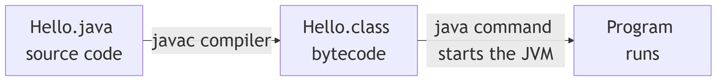

*Figure 3.1 — From source code to a running program*

*Text description:* Three boxes in a row, read left to right. The source file `Hello.java` is turned into `Hello.class` bytecode by the `javac` compiler, and the `java` command then starts the JVM, which runs the bytecode as a program.

You install the **JDK** (Java Development Kit), which contains the compiler, the JVM and the standard library, a large collection of ready-made code. The **JRE** (Java Runtime Environment) is the part needed only to run programs, without the compiler; you will meet it in the Dockerfile in Chapter 10. This book uses Java 25, a long-term-support release, which the project selected when it upgraded (Chapter 6). The project sets `<java.version>25</java.version>` in its `pom.xml`. **Analogy.** Source code is a recipe in English, bytecode is the same recipe translated into a simple universal shorthand, and the JVM is a cook in each kitchen who knows the shorthand.

**Where the analogy breaks down:** a cook works from the shorthand at human speed, while the JVM also optimizes the bytecode as it runs, so long-running programs get faster after a warm-up. And a cook may improvise, while the JVM does exactly what the bytecode says.

### 3.2 Hello, world: compile and run

Check that Java is installed:

```bash
java -version
```

You should see something like this:

```
openjdk version "25" ...
```

The exact wording varies with the vendor and patch level (you may see `25.0.1`, or `java version "25..."`); what matters is the 25.

If you get "command not found", the JDK is not installed or not on your `PATH` (Chapter 2). Also check the compiler: `javac -version` should print `javac 25...`.

Create a file named `Hello.java` with the code in Example 3.1. The filename must match the class name.

**Example 3.1 — `Hello.java`**

```java
public class Hello {
    public static void main(String[] args) {
        System.out.println("Hello, world");
    }
}
```

Every token here is new, so we go through it.

- `public class Hello { ... }` declares a **class**, a named container for code. Chapter 4 explains classes fully. For now, every Java program lives inside one, and the name matches the file.
- `public static void main(String[] args)` declares the **main method**, the entry point: where the JVM starts. The words `public` and `static` control who can call it and whether it needs an object; `void` means it returns nothing; `String[] args` receives any words typed after the program name.
- `System.out.println("Hello, world");` prints a line of text. `"Hello, world"` is a **string**, a piece of text in double quotes. The semicolon ends the statement.
- Braces `{ }` group code into blocks.

Compile and run:

```bash
javac Hello.java
java Hello
```

`javac` creates `Hello.class`; `java Hello` runs it. You should see:

```
Hello, world
```

Since Java 11 you can also run a single file in one step with `java Hello.java`, which compiles in memory and runs. This book uses it for small examples.

The real application has the same shape. Its entry point is short.

**Listing 3.1 — `SecureDocViewerApplication.java` (book-m6-final)**

```java
package com.example.securedocviewer;

import org.springframework.boot.SpringApplication;
import org.springframework.boot.autoconfigure.SpringBootApplication;
import org.springframework.scheduling.annotation.EnableScheduling;

@SpringBootApplication
@EnableScheduling
public class SecureDocViewerApplication {
    public static void main(String[] args) {
        SpringApplication.run(SecureDocViewerApplication.class, args);
    }
}
```

*Path: `src/main/java/com/example/securedocviewer/SecureDocViewerApplication.java`*

You recognize the class and `main`. The `package` and `import` lines and the `@` lines are explained in Chapter 4. The single line inside `main` starts the whole web server; Chapter 11 explains how.

### 3.3 Variables, types, and operators

A **variable** is a named place to keep a value. Java is **statically typed**: every variable has a **type** that says what kind of value it holds, and the compiler checks that you use it correctly. Table 3.1 lists the types you will meet most.

Table 3.1 — Basic types

| Type | Holds | Example |
| --- | --- | --- |
| `int` | Whole numbers (about -2 billion to 2 billion) | `512` |
| `long` | Larger whole numbers | `120L` |
| `double` | Decimal numbers | `1.5` |
| `boolean` | `true` or `false` | `true` |
| `String` | Text | `"admin"` |

Example 3.2 declares some variables using names from the app's configuration.

**Example 3.2 — Variables and operators**

```java
int tileSize = 512;
int pageWidthPx = 1275;
String owner = "pub.one";
boolean isPrivate = true;

int leftover = pageWidthPx - 2 * tileSize;   // 1275 - 1024 = 251
boolean fits = pageWidthPx <= tileSize;      // false
String label = owner + " owns this";         // text joining
```

Each line has the shape `type name = value;`. The `=` **assigns**: it stores the value on the right in the variable on the left. **Operators** combine values: `+ - * /` for arithmetic, `<=`, `<`, `==` (equal), `!=` (not equal) for comparison, and `&&` (and), `||` (or), `!` (not) for booleans. With `+`, text and other values are joined. Names follow a convention: start with a lowercase letter and capitalize each later word (`pageWidthPx`), called **camel case**. Java is case-sensitive, so `tileSize` and `TileSize` are different names.

Two more pieces of vocabulary. A variable declared `final` cannot be changed after it is set, which is the right choice for a value that should stay fixed. And a number written directly in code, such as `512`, is a **literal**. When the same number matters in several places, give it a name so its meaning is clear.

Three details trip up beginners. Dividing two `int` values gives an `int` with the remainder dropped: `7 / 2` is `3`, not `3.5`. To keep the fraction, at least one side must be a `double`: `7 / 2.0` is `3.5`. Assigning a decimal to an `int` variable is an error, because it would lose information (Section 3.8 shows the message). And `==` compares numbers; to compare text, use `.equals`: `owner.equals("pub.one")`. The reason is that a `String` is an object (Chapter 4), and `==` on objects asks "are these the very same object?", not "do they hold the same text?".

### 3.4 Strings

Text is everywhere in the app, from usernames to document titles, so it is worth knowing how Java treats it.

A `String` is a sequence of characters, and you can ask questions of it with methods. `text.length()` counts its characters, `text.isBlank()` is true if it is empty or only spaces, `text.toUpperCase()` returns an uppercase copy, and `text.substring(0, 3)` returns the first three characters. A `String` never changes: every method that seems to modify it returns a new one.

One more subtlety of text, the difference between a character and a byte, caused a real bug in this project. It is not needed yet, so it waits in Section 3.10 in the Advanced tier.

## Intermediate tier: Control flow and methods

*On a first read you can skim this tier; Chapters 4 and 5 use these ideas again.*

### 3.5 Decisions

An **if statement** runs code only when a condition is true. Add `else` for the other case, and `else if` for more.

**Example 3.3 — Deciding**

```java
if (pageCount > 500) {
    System.out.println("Too many pages");
} else if (pageCount == 0) {
    System.out.println("Empty document");
} else {
    System.out.println("OK");
}
```

The conditions are checked from the top, and only the first true branch runs. The 500-page limit in the example is the project's real maximum (`max-pages: 500` in `application.yml`). When you are choosing among many fixed values, a **switch** reads better than a chain of `if`. Suppose you want a sentence about each account role. `Role` is a type with a fixed set of values, which Chapter 4 calls an enum, and the compiler checks that you covered every value.

**Example 3.4 — Switch on a fixed set of values (teaching example)**

```java
public class Roles {
    enum Role { READER, PUBLISHER, ADMIN }

    static String describe(Role role) {
        return switch (role) {
            case READER -> "may read documents shared with them";
            case PUBLISHER -> "may also upload documents";
            case ADMIN -> "may also manage accounts and see the audit log";
        };
    }

    public static void main(String[] args) {
        System.out.println(describe(Role.PUBLISHER));   // may also upload documents
    }
}
```

`switch` here is an expression: it produces a value, which the method returns. Each `case X -> value` is one branch. If you delete one case, the compiler refuses to compile, which turns "I forgot a role" into an error you see immediately. The role descriptions follow the project's own comment on `Role`. The real app uses a switch of a more advanced kind in its error handler; you will read it in Chapter 13.

### 3.6 Loops

A **loop** repeats code. A `for` loop counts:

**Example 3.5 — Counting**

```java
for (int row = 0; row < 4; row++) {
    System.out.println("Row " + row);
}
```

Read the parentheses as three parts: start (`int row = 0`), keep going while (`row < 4`), and step (`row++`, which adds one). This prints rows 0 to 3. Counting starts at zero throughout Java, and the app follows that: the first tile of a page is row 0, column 0.

A `while` loop repeats as long as a condition holds. It suits cases where you do not know in advance how many rounds you need:

**Example 3.6 — Counting tiles the slow way**

```java
int covered = 0;
int cols = 0;
while (covered < 1275) {
    covered += 512;   // shorthand for covered = covered + 512
    cols++;
}
System.out.println(cols);   // 3
```

Each round adds one tile's width until the page width is covered. It gives the same answer as the formula in Section 3.7, three columns, by repetition instead of arithmetic. Two keywords change a loop's flow: `break` leaves the loop at once, and `continue` skips to the next round.

The app uses exactly the counting pattern to hand out one URL per tile, with one loop inside another.

**Listing 3.2 — `PageTileUrlController.java` (book-m6-final, excerpt: method `tileUrls`)**

```java
        String[][] urls = new String[pageInfo.rows()][pageInfo.cols()];
        for (int row = 0; row < pageInfo.rows(); row++) {
            for (int col = 0; col < pageInfo.cols(); col++) {
                String token = signedUrlService.issueToken(documentId, page, row, col, issuable.tileVersion(), sessionBinding);
                urls[row][col] = "/api/tiles?token=" + token;
            }
        }
```

*Path: `src/main/java/com/example/securedocviewer/controller/PageTileUrlController.java`*

The outer loop walks the rows, and the inner loop walks the columns of each row. Each pass creates a **token**, the signed part of a URL, and stores a URL in `urls`. The variable `urls` is a table of strings: `String[][]` is a two-dimensional **array**, a fixed-size row of values. Names like `pageInfo.rows()` and `signedUrlService.issueToken(...)` are calls to code defined elsewhere; you will learn to read them in Chapter 4. A page that is 3 columns by 4 rows makes the inner statement run 12 times, once per tile.

A common source of bugs is stepping one too far. `for (int i = 0; i <= 4; i++)` runs five times, not four. Prefer `<` with a count, as in Listing 3.2, and remember that an array of length 4 has indexes 0 to 3.

### 3.7 Methods

A **method** is named, reusable code that takes inputs (**parameters**) and can give back a result (a **return value**). Methods stop you from writing the same logic twice and let you test it in isolation.

**Example 3.7 — A method**

```java
static int tilesNeeded(int lengthPx, int tileSize) {
    return (lengthPx + tileSize - 1) / tileSize;
}
```

`static int tilesNeeded(...)` says: this method returns an `int`. Inside the parentheses are two parameters, each with a type. `return` sends a value back. You call it like this: `int cols = tilesNeeded(1275, 512);`, and `cols` becomes 3.

Why that formula? Whole-number division drops the remainder, so `1275 / 512` is 2, one tile short. Adding `tileSize - 1` first makes any remainder push the result up to the next whole number. This is **ceiling division**, "divide and round up." Check it by hand: `(1275 + 511) / 512` is `1786 / 512`, which is 3 after dropping the remainder. And for an exact fit, `(1024 + 511) / 512` is `1535 / 512`, which is 2, correct. The app needs it because a page rarely divides evenly into tiles.

A method that returns nothing is declared `void` (like `main`) and does something instead, such as printing. Methods can call other methods, and each call gets its own set of variables. Parameters are **passed by value**: the method receives a copy of a number, so changing the parameter inside the method does not change the caller's variable. Methods are also how you split a big problem: `main` in a real program is usually short, and calls methods that each do one thing well.

**Example 3.8 — Methods calling methods**

```java
public class Grid {
    static int tilesNeeded(int lengthPx, int tileSize) {
        return (lengthPx + tileSize - 1) / tileSize;
    }

    static int totalTiles(int widthPx, int heightPx, int tileSize) {
        return tilesNeeded(widthPx, tileSize) * tilesNeeded(heightPx, tileSize);
    }

    public static void main(String[] args) {
        System.out.println(totalTiles(1275, 1650, 512));   // 12
    }
}
```

The total is columns times rows: 3 times 4, which is 12, the number quoted in Chapter 1.

### 3.8 Reading errors

Errors are normal. You will read many. Learn to read them calmly, from the first line.

A **compiler error** stops the build before anything runs. Suppose you forget a semicolon:

```
Hello.java:3: error: ';' expected
        System.out.println("Hello, world")
                                          ^
1 error
```

The message gives the file, the line number (3), what is wrong, and a caret under the place. Fix the first error first; later ones often follow from it. Two more you will meet often:

```
Hello.java:3: error: cannot find symbol
        System.out.printn("Hello, world");
                  ^
  symbol:   method printn(String)
  location: variable out of type PrintStream
```

"Cannot find symbol" means a name is misspelled, or in the wrong case, or was never declared or imported. Here `printn` should be `println`. And:

```
Tiles.java:4: error: incompatible types: possible lossy conversion from double to int
        int cols = 1275 / 512.0;
                        ^
```

You put a decimal result into an `int`. Java refuses, because the fraction would be lost silently; this is the "types protect you" behavior of a statically typed language. The fix is to choose the right type, or to convert on purpose.

A **runtime error** happens while the program runs. Java reports it as an **exception** with a **stack trace**, the chain of method calls that led to the failure, newest first:

```
Exception in thread "main" java.lang.IllegalArgumentException: lengthPx and tileSize must both be positive
        at TileMath.tileCount(TileMath.java:6)
        at TileMath.main(TileMath.java:12)
```

Read it top to bottom: the first line says what went wrong, and the first `at` line says where. Here that is line 6 of `TileMath.java`, called from line 12. (This trace is teaching output, not from the project.) Another common one is `ArrayIndexOutOfBoundsException: Index 3 out of bounds for length 3`, which means you asked for the fourth item of a three-item array. Chapter 5 teaches how to raise and handle exceptions.

## Advanced tier: Real code from the app

*On a first read you can skip to "In this project"; Chapter 13 returns to validation.*

### 3.9 A small taste of the app: tile-grid math and its test

You now know enough to read a real class. `TileGrid` holds the math that turns a page's pixel size into a number of tiles. Listing 3.3 is its counting method.

**Listing 3.3 — `TileGrid.java` (book-m6-final, excerpt: method `tileCount`)**

```java
    /** Number of tiles needed to cover {@code lengthPx} pixels: ceil(lengthPx / tileSize). */
    public static int tileCount(int lengthPx, int tileSize) {
        if (lengthPx <= 0 || tileSize <= 0) {
            throw new IllegalArgumentException("lengthPx and tileSize must both be positive");
        }
        return (lengthPx + tileSize - 1) / tileSize;
    }
```

*Path: `src/main/java/com/example/securedocviewer/service/TileGrid.java`*

Line by line:

- The `/** ... */` block is a **doc comment**: text for people, ignored by the compiler.
- `public static int tileCount(int lengthPx, int tileSize)` is a method that returns a whole number. `public` lets any code call it.
- The `if` uses `||` ("or"): if either input is zero or negative, the method refuses to continue.
- `throw new IllegalArgumentException(...)` raises an exception with a message. Refusing bad input early stops a nonsense answer from spreading.
- The final line is the ceiling division from Section 3.7.

The project tests this method with a synthetic image so it never needs a real PDF. That is why the class is kept separate from PDF rendering, as its own comment says. A **test** is code that checks other code. Here are two of the project's tests for `tileCount`, and you can already read them.

**Listing 3.4 — `TileGridTest.java` (book-m6-final, excerpt: two tests)**

```java
    @Test
    void tileCountRoundsUpForPartialTiles() {
        assertEquals(1, TileGrid.tileCount(1, 256));
        assertEquals(1, TileGrid.tileCount(256, 256));
        assertEquals(2, TileGrid.tileCount(257, 256));
        assertEquals(13, TileGrid.tileCount(612, 50));
        assertEquals(16, TileGrid.tileCount(792, 50));
    }

    @Test
    void tileCountRejectsNonPositiveInputs() {
        assertThrows(IllegalArgumentException.class, () -> TileGrid.tileCount(0, 256));
        assertThrows(IllegalArgumentException.class, () -> TileGrid.tileCount(100, 0));
    }
```

*Path: `src/test/java/com/example/securedocviewer/service/TileGridTest.java`*

`assertEquals(expected, actual)` fails the test if the two values differ. Check the last two. A US letter page is 612 by 792 points. With 50-pixel tiles you need 13 columns, because `612 / 50` is 12.24, which rounds up to 13. You need 16 rows, because `792 / 50` is 15.84, which rounds up to 16. The tests choose their inputs on the edges: one pixel, exactly one tile, one pixel more than a tile. Those are where a rounding formula goes wrong. `assertThrows` checks that bad input raises the exception, using a small unnamed method, a lambda (Chapter 5). The test class is `TileGridTest`; the testing chapters (18 and 24) teach how tests are run.

The same file holds the guarantee that gave the class its shape. Its own comment states: "tiles are a lossless partition of the page. Reassembling every tile at its grid offset must reproduce the source image pixel-for-pixel — no seams, no overlap, no dropped edge strips." A test builds a random image whose size is not a multiple of the tile size (613 by 457 with 64-pixel tiles). It slices the image, reassembles it, and compares every pixel. The lesson is bigger than the code: when a class has one clear promise, write the test that proves it.

### 3.10 Characters, bytes, and a real limit

This section is a first look at a subtle point. If it feels heavy, read it once and return to it after Chapter 5; nothing later in Part I depends on it.

Text deserves a closer look here, because a real bug in this project came from misunderstanding it.

Computers store everything as bytes (Chapter 2), so a string must be **encoded** into bytes to be saved or sent. In UTF-8, plain English letters take one byte each, but accented letters take two, and many symbols and emoji take three or four. So the number of characters and the number of bytes can differ, and a program must know which one a rule is about.

**Example 3.9 — Characters versus bytes**

```java
import java.nio.charset.StandardCharsets;

public class Bytes {
    public static void main(String[] args) {
        String plain = "password";
        String accented = "contraseña";
        System.out.println(plain.length());                                       // 8
        System.out.println(plain.getBytes(StandardCharsets.UTF_8).length);        // 8
        System.out.println(accented.length());                                    // 10
        System.out.println(accented.getBytes(StandardCharsets.UTF_8).length);     // 11
    }
}
```

`getBytes(StandardCharsets.UTF_8)` turns the string into its UTF-8 bytes, and `.length` counts them. The word `contraseña` (the Spanish for "password") has 10 characters but 11 bytes, because `ñ` takes two.

Why does this matter here? The app stores passwords using BCrypt, a **hashing** method (a one-way scrambling of a password, so the original cannot be recovered; Chapter 15) that reads at most 72 bytes of a password and refuses longer ones. So the rule "how long may a password be?" is really a rule about bytes. Here is how the app expresses it.

**Listing 3.5 — `UserAccountService.java` (book-m6-final, excerpt: the byte limit)**

```java
    /** BCrypt uses at most 72 bytes of a password and refuses longer ones. */
    public static final int MAX_PASSWORD_BYTES = 72;

    public static boolean fitsBcrypt(String password) {
        return password == null || password.getBytes(java.nio.charset.StandardCharsets.UTF_8).length <= MAX_PASSWORD_BYTES;
    }
```

*Path: `src/main/java/com/example/securedocviewer/account/UserAccountService.java`*

`public static final int MAX_PASSWORD_BYTES = 72;` is a named constant (`final` means it never changes; `static` means it belongs to the class itself; Chapter 4 explains). `fitsBcrypt` returns a `boolean`: true if the password is missing (`null`, treated as "nothing to reject here") or if its UTF-8 byte count is at most 72. It is a method with one input and one true-or-false answer, the simplest useful kind. Section 3.11 shows where it is used, and Chapter 5 tells the bug this rule fixed.

### 3.11 Validating input: the password rule

Real programs spend much of their time rejecting bad input politely. Here is the app's rule for a new password, built from the pieces of this chapter.

**Listing 3.6 — `UserAccountService.java` (book-m6-final, excerpt: method `requireAcceptablePassword`)**

```java
    private static void requireAcceptablePassword(String password) {
        if (password == null || password.length() < MIN_PASSWORD_LENGTH || password.length() > MAX_PASSWORD_LENGTH) {
            throw new BadRequestException("Password must be " + MIN_PASSWORD_LENGTH + "-" + MAX_PASSWORD_LENGTH
                    + " characters long.");
        }
        if (!fitsBcrypt(password)) {
            throw new BadRequestException("Password is too long: at most " + MAX_PASSWORD_BYTES
                    + " bytes (fewer characters if it uses accents, non-Latin letters or emoji).");
        }
        if (password.isBlank()) {
            throw new BadRequestException("Password can't be only whitespace.");
        }
    }
```

*Path: `src/main/java/com/example/securedocviewer/account/UserAccountService.java`*

Read it as a checklist. The first `if` rejects a missing password or one shorter than 12 characters or longer than 128 (the constants `MIN_PASSWORD_LENGTH` and `MAX_PASSWORD_LENGTH`). The second rejects one that does not fit BCrypt's 72 bytes, using `fitsBcrypt` from Listing 3.5; the `!` means "not". The third rejects a password that is only spaces. Each failure throws a `BadRequestException` with a message a user can act on, and the message even explains that accents and emoji use more than one byte per character. The `+` joins text and numbers into a sentence. `private static void` means: only this class may call it, it belongs to the class, and it returns nothing (it either returns quietly or throws).

Notice the order of the checks. The cheap and most common problems come first, and the byte check comes after the length check, because it is the subtle one. Notice also that validation happens at the door of the code, before anything is stored. Chapter 13 shows the framework's own validation, and Chapter 15 shows what happens to the password next.

### 3.12 Common mistakes

**Missing semicolon or brace.** The compiler names the line, but the mistake is often on the previous line. Check that every `{` has a `}`.

**`=` versus `==`.** `=` assigns and `==` compares. `if (x = 5)` will not compile; `if (x == 5)` is what you meant.

**Integer division.** `7 / 2` is `3`. If you need a fraction, make one side a `double`.

**Off by one.** Using `<=` where you meant `<`, or forgetting that counting starts at zero. Test the first and last cases by hand.

**Comparing strings with `==`.** Use `.equals`.

**File and class name mismatch.** A `public class Hello` must live in `Hello.java`, or the compiler says "class Hello is public, should be declared in a file named Hello.java". Rename one of them.

**"cannot find symbol."** A typo, a wrong case, or a missing `import`. Java is case-sensitive: `String` and `string` are different.

**Forgetting `static`.** In a small program, calling a method from `main` that is not `static` gives "non-static method cannot be referenced from a static context." Add `static` for now; Chapter 4 explains when you should not.

**Counting characters when the rule is about bytes.** As Section 3.10 showed, the two can differ. Decide which one your rule is about.

## In this project

- `src/main/java/com/example/securedocviewer/SecureDocViewerApplication.java`: the entry point.
- `src/main/java/com/example/securedocviewer/service/TileGrid.java`: the tile math, with its tests in `src/test/java/com/example/securedocviewer/service/TileGridTest.java`.
- `src/main/java/com/example/securedocviewer/controller/PageTileUrlController.java`: the nested loop.
- `src/main/java/com/example/securedocviewer/account/UserAccountService.java`: the password rule.

## Try it

### Exercise 3.1 ★ Hello, tiles

Write `Tiles.java` with a `main` that prints how many columns and rows a 1275 by 1650 page needs at 512 pixels, using the formula from Section 3.7. Compile and run it.

*Solution:* Appendix C, Exercise 3.1.

### Exercise 3.2 ★ Break it on purpose

Remove the semicolon from your `println` line and compile. Then restore it and change `main` to `mian`, compile, and run. Describe each message.

*Hint:* one fails at compile time, one at launch.

*Solution:* Appendix C, Exercise 3.2.

### Exercise 3.3 ★★ Print the grid

Extend `Tiles.java` with two nested `for` loops that print each tile as `row,col`, one per line. How many lines do you expect for a 1275 by 1650 page?

*Solution:* Appendix C, Exercise 3.3.

### Exercise 3.4 ★ Characters or bytes

Run Example 3.9 with a string of your own that contains at least one accented letter. Predict the two numbers before you run it.

*Solution:* Appendix C, Exercise 3.4.

### Exercise 3.5 ★★ Write a rule

Write a method `static boolean validTitle(String title)` that returns true only if the title is not blank and at most 200 characters (the size of the `title` column; Chapter 9 explains columns). Test it with an empty string, a string of spaces, a normal title, and a 201-character string.

*Solution:* Appendix C, Exercise 3.5.

### Exercise 3.6 ★★★ Test your own method

Write a `main` that calls `tilesNeeded` with the same edge cases the project's test uses (1, exactly one tile, one more than a tile) for a tile size of 256, and prints `PASS` or `FAIL` for each by comparing with the expected values 1, 1 and 2. Then add a fourth check that a zero length is rejected: make `tilesNeeded` throw `IllegalArgumentException` and catch it in `main`.

*Solution:* Appendix C, Exercise 3.6.

## Summary

- Java source is compiled by `javac` to bytecode, which the JVM runs; the JDK contains both.
- Variables have types; `int` division drops the remainder; a `String` is not compared with `==`.
- Characters and bytes are different things, and the app's password limit is about bytes.
- `if` and `switch` decide, `for` and `while` repeat, and methods package logic behind a name.
- Errors are read from the first line: the message, then the location.
- `TileGrid.tileCount` is ceiling division guarded by a check that throws an exception, and its tests choose edge cases on purpose.
- Validation rejects bad input early, in order, with messages a person can act on.

## Further reading

- *The Java Tutorials*, "Getting Started." https://docs.oracle.com/javase/tutorial/getStarted/index.html
- *The Java Tutorials*, "Language Basics." https://docs.oracle.com/javase/tutorial/java/nutsandbolts/index.html
- *Java Platform SE 25 API*, `java.lang.String`. https://docs.oracle.com/en/java/javase/25/docs/api/

# Chapter 4: Classes, objects, records, and interfaces

Chapter 3 gave you values, decisions, loops, and methods. Real programs group these into larger pieces that model things: an account, a document, a tile. This chapter teaches classes and objects, records, enums, interfaces, packages, and annotations, using the app's own account and document types as the examples. It also shows how objects are wired together, and tells the story of a bug that came from an object that was too trusting.

## Learning objectives

By the end of this chapter, you will be able to:

- Explain the difference between a class and an object.
- Write a class with private fields, a constructor, getters, and a method that keeps a rule true.
- Write a record and say when a record is a better choice than a class.
- Write an enum for a fixed set of choices.
- Explain what an interface is and why the app depends on interfaces.
- Explain how objects receive the other objects they need.
- Read a `package` line, an `import` line, and a source-folder layout, and name the four access levels.
- Recognize an annotation and say what it is for.

## Prerequisites

- Chapter 3: Your first Java program

## Beginner tier: Modeling things

### 4.1 Classes and objects; fields, constructors

Suppose the app must keep track of accounts. Each account has a username, a role and a creation time. You could use three separate variables, but you would need a new set for every account. A class is a blueprint that groups such values together with the code that works on them. An **object** is one thing built from that blueprint. A class is "account"; the account for `pub.one` is an object of that class, and the account for `reader.one` is another object of the same class.

**Analogy.** A class is a form with blank fields, and each object is a filled-in copy.

**Where the analogy breaks down:** in two ways. The same form can produce as many copies as you like while the program runs, and each copy is independent: changing one does not touch the others. And an object lives in the computer's memory only while the program runs; it disappears when the program ends unless the app saves it, which is what the database is for (Chapter 9). Unlike a paper form, a class can also carry behavior: it holds methods, not only blanks.

The values an object holds are its **fields**. A **constructor** is special code that runs when you create an object with `new`, and sets up its fields. Example 4.1 is a tiny teaching class, not the project's.

**Example 4.1 — A minimal class**

```java
public class Account {
    String username;
    int failedAttempts;

    Account(String username) {
        this.username = username;
        this.failedAttempts = 0;
    }

    void recordFailure() {
        failedAttempts = failedAttempts + 1;
    }
}
```

The constructor has the class's name and no return type. `this` means "this object," so `this.username = username` copies the parameter into the field. The method `recordFailure` belongs to each account and changes that account's own field. Creating and using objects:

```java
Account a = new Account("pub.one");
Account b = new Account("reader.one");
a.recordFailure();
a.recordFailure();
System.out.println(a.failedAttempts);   // 2
System.out.println(b.failedAttempts);   // 0
```

The dot reaches into an object: `a.username` is the field, and `a.recordFailure()` calls a method. The two objects are independent: `a` has two failures and `b` still has none. To try it, put a `main` method in a class and run it as in Chapter 3.

### 4.2 Encapsulation: private, getters, and rules that stay true

If any code can change `a.failedAttempts`, then any bug anywhere can corrupt it. **Encapsulation** means hiding a class's fields and exposing only the operations you intend. You mark fields `private` (only this class can touch them) and offer **getter** methods to read them and, where change is allowed, **setter** methods to write them.

The app's real account class follows this pattern. Here it is, shortened to the parts we need.

**Listing 4.1 — `AppUser.java` (book-m6-final, simplified: imports, the fields `enabled`, `createdAt`, `mustChangePassword` and `lastSignInAt`, and the accessors of `role`, `enabled` and those fields omitted; the `// ...` lines mark the cuts)**

```java
@Entity
@Table(name = "app_user")
public class AppUser {

    @Id
    @GeneratedValue(strategy = GenerationType.IDENTITY)
    private Long id;

    @Column(nullable = false, unique = true, length = 64)
    private String username;

    @Column(name = "password_hash", nullable = false, length = 100)
    private String passwordHash;

    @Enumerated(EnumType.STRING)
    @Column(nullable = false, length = 20)
    private Role role;

    // ...

    protected AppUser() {
    }

    public AppUser(String username, String passwordHash, Role role) {
        this.username = username;
        this.passwordHash = passwordHash;
        this.role = role;
        this.createdAt = Instant.now();
    }

    public Long getId() {
        return id;
    }

    public String getUsername() {
        return username;
    }

    public String getPasswordHash() {
        return passwordHash;
    }

    public void setPasswordHash(String passwordHash) {
        this.passwordHash = passwordHash;
    }

    // ...
}
```

*Path: `src/main/java/com/example/securedocviewer/account/AppUser.java`*

Notice four things:

- Every field is `private`. Other code must go through methods.
- There is a getter for `username` but no setter. Once created, an account's username cannot be changed through this class; that is a deliberate rule, written into the code's shape. Other fields, such as `role`, do have setters (cut from the listing), because an administrator can change them.
- There is a setter for `passwordHash`, because passwords change.
- The public constructor takes the three values a new account needs. It sets the creation time itself, so no caller can forget or fake it. The `protected` constructor with no parameters exists for the database library, which Chapter 14 explains. `Long` with a capital L is the object form of `long` (Chapter 5), which can be `null` before the database assigns the number.

A field with no setter and set only in the constructor is **immutable**: it never changes after creation. Immutable data is easier to reason about, because nothing can alter it behind your back. `Instant.now()` gives the current moment as a point in time, which Chapter 5 explains.

The best reason for setters instead of public fields is that a setter can do more than assign. Look at how the project's `Document` class keeps its "last updated" time honest.

**Listing 4.2 — `Document.java` (book-m6-final, simplified: imports, fields and unrelated methods omitted)**

```java
    public void touch() {
        this.updatedAt = Instant.now();
    }

    // ...

    public void setTitle(String title) {
        this.title = title;
        touch();
    }

    // ...

    public void setVisibility(Visibility visibility) {
        this.visibility = visibility;
        touch();
    }
```

*Path: `src/main/java/com/example/securedocviewer/document/Document.java`*

Every setter that changes the document also calls `touch()`, which updates `updatedAt`. No caller has to remember to do it, and no caller can forget. If `title` were a public field, someone would eventually change it directly and the "last updated" time in the library page would be wrong. This is encapsulation doing real work: the class guarantees a rule about its own data. The `Role` type of the `role` field is an enum, which we meet in Section 4.4. The `@` lines are annotations, covered in Section 4.8.

### 4.3 Records for plain data

Many types are plain bundles of values that never change: a page's dimensions, a row of a table. Writing a private field, constructor, and getter for each is repetitive. A **record** gives you all of that in one line. When you declare `record Point(int x, int y) { }`, Java generates the constructor, the read methods `x()` and `y()`, and sensible `equals`, `hashCode` and `toString`. `equals` decides whether two objects count as the same value; `hashCode` is a fingerprint that collections use (Chapter 5); `toString` produces readable text. Record fields are always immutable.

The app uses records everywhere data moves around. Here is one describing a rendered page.

**Listing 4.3 — `PageInfo.java` (book-m6-final)**

```java
package com.example.securedocviewer.model;

/**
 * Describes the tile grid for a single rendered page, plus the pixel
 * dimensions the frontend needs to lay tiles out on a &lt;canvas&gt;.
 */
public record PageInfo(
        int page,
        int rows,
        int cols,
        int tileSize,
        int pageWidthPx,
        int pageHeightPx
) {
}
```

*Path: `src/main/java/com/example/securedocviewer/model/PageInfo.java`*

A note on the comment: it mentions a `<canvas>`, a drawing surface in the browser. That comment dates from the first milestone, whose static page drew tiles on a canvas. The Angular viewer in the finished app instead positions plain `div` elements and paints each tile as a CSS background image (CSS, Cascading Style Sheets, is the language that styles web pages; Chapter 21), so the comment is stale at `book-m6-final`. A later documentation-only pull request (number 13, merged into `main` after the tag) corrected this comment in `PageInfo.java` and the matching sentence in the README, so a reader who clones `main` will not find it; the tags still say canvas. The record itself is unaffected. You create one with `new PageInfo(1, 4, 3, 512, 1275, 1650)` and read it with `info.rows()`. Note that the read method is `rows()`, not `getRows()`. Listing 3.2 in Chapter 3 used exactly this: `pageInfo.rows()` and `pageInfo.cols()`. Records also compare by value, which a plain class does not:

**Example 4.2 — Records compare by value (teaching example)**

```java
public class RecordDemo {
    record TileRef(int row, int col) { }

    public static void main(String[] args) {
        TileRef a = new TileRef(2, 1);
        TileRef b = new TileRef(2, 1);
        System.out.println(a);            // TileRef[row=2, col=1]
        System.out.println(a.equals(b));  // true
        System.out.println(a == b);       // false: two different objects
    }
}
```

`a.equals(b)` is true because the values match, even though `a == b` is false, since they are two objects. That is what you want for data such as a tile position. A record can also contain methods. The signed-URL payload adds one that joins its fields into the text that gets signed.

**Listing 4.4 — `SignedTilePayload.java` (book-m6-final, simplified: comments omitted)**

```java
public record SignedTilePayload(
        String documentId,
        int page,
        int row,
        int col,
        int tileVersion,
        String sessionBinding,
        long expiresAtEpochSeconds
) {
    public String canonicalString() {
        return documentId + "|" + page + "|" + row + "|" + col + "|" + tileVersion + "|" + sessionBinding + "|" + expiresAtEpochSeconds;
    }
}
```

*Path: `src/main/java/com/example/securedocviewer/model/SignedTilePayload.java`*

Why a record here? A signed payload must not change between the moment it is signed and the moment it is checked, and a record cannot be altered after creation. Chapter 17 explains what the signature covers.

Records can also have **static methods**, which belong to the type and not to an object. Two real examples show a common pattern: a method that builds the record from something else. First, `Viewer`, the record the app uses to mean "the signed-in user an operation is for."

**Listing 4.5 — `Viewer.java` (book-m6-final, simplified: imports omitted)**

```java
/** The signed-in user a document operation is performed for. */
public record Viewer(String username, boolean admin, boolean publisher) {

    public static Viewer of(Authentication authentication) {
        boolean admin = hasRole(authentication, "ROLE_ADMIN");
        return new Viewer(authentication.getName(), admin, admin || hasRole(authentication, "ROLE_PUBLISHER"));
    }

    private static boolean hasRole(Authentication authentication, String role) {
        return authentication.getAuthorities().stream().anyMatch(a -> role.equals(a.getAuthority()));
    }
}
```

*Path: `src/main/java/com/example/securedocviewer/document/Viewer.java`*

`Viewer.of(...)` is a **static factory method**: called on the type, not on an object, and it returns a new `Viewer`. It reads the framework's `Authentication` object once and turns it into three plain facts: a username and two booleans. Note that an admin is also treated as a publisher (`admin || ...`), so code elsewhere need only ask `publisher()`. And the private helper `hasRole` uses the `anyMatch` stream idea of Chapter 5. The second example is a record nested inside another record.

**Listing 4.6 — `AuditEvent.java` (book-m6-final, excerpt: the nested record `Actor`)**

```java
    /** Who did it and from where; attached to every event recorded during a request. */
    public record Actor(String username, String sessionHandle, String clientIp) {
        public static Actor anonymous(String clientIp) {
            return new Actor(null, null, clientIp);
        }
    }
```

*Path: `src/main/java/com/example/securedocviewer/audit/AuditEvent.java`*

An `Actor` says who did something and from where. "Who" is the username and a session handle, a short stand-in for the session's identifier that is safe to show (Chapter 16). "From where" is the client address. `anonymous` builds one for a request with no signed-in user, where the first two are `null`. Naming the situation (`Actor.anonymous(ip)`) reads better than `new Actor(null, null, ip)`.

**When to choose which.** Use a record for plain data that does not change. Use a class when the object has changing state or must hide its fields, as `AppUser` does because the database library fills it in and updates it. Table 4.1 sums up the choice.

Table 4.1 — Class or record

| Aspect | Class | Record |
| --- | --- | --- |
| Fields | You declare them, usually `private` | Listed in the header, always `private final` |
| Changes after creation | Allowed, if you write setters | Never |
| `equals` and `toString` | You write them, or get identity comparison | Generated, by value |
| Typical use in the app | `AppUser`, `Document`, services | `PageInfo`, `Viewer`, `Actor`, `AuditEvent` |

### 4.4 Enums for fixed choices

Some values come from a short, fixed list. An account's role is `READER`, `PUBLISHER` or `ADMIN`, and nothing else. If you stored roles as free text, a typo such as `"ADMlN"` would compile and fail silently later. An **enum** declares the complete list, and the compiler rejects anything else.

**Listing 4.7 — `Role.java` (book-m6-final)**

```java
package com.example.securedocviewer.account;

/**
 * What an account may do. Roles are cumulative in practice: every signed-in
 * user can read documents they have access to, publishers can also upload,
 * and admins can additionally manage accounts, sessions and the audit log.
 */
public enum Role {
    READER,
    PUBLISHER,
    ADMIN
}
```

*Path: `src/main/java/com/example/securedocviewer/account/Role.java`*

You write `Role.ADMIN` in code, and compare with `==`: `user.getRole() == Role.ADMIN`. Two useful methods exist on every enum: `name()` returns the value as text (`"ADMIN"`), and `values()` returns them all. The database stores the name as text, which is what the annotation `@Enumerated(EnumType.STRING)` in Listing 4.1 asks for: the `role` column holds `'ADMIN'`, not a number. Storing the name rather than the position is deliberate. If someone reorders the enum, positions change but names do not, so old rows keep their meaning.

The project has a second enum, `Visibility`, with the values `PRIVATE` and `EVERYONE`. It is the answer to "besides the owner and admins, who may open this document?". And a third, `AuditEventType`, lists the 22 kinds of event the audit trail records (`SIGN_IN`, `PAGE_VIEWED`, `ACCESS_DENIED`, and so on); a new kind of event means adding a value there. The compiler then helps you find every `switch` that must handle it. Chapter 3's `switch` example works on exactly this kind of type.

## Intermediate tier: Depending on promises, and wiring objects together

A note on pacing. This tier and the next show a few real listings that use things you have not met yet. One is the framework Spring (Part II). Another is tests (Chapter 18). The last is two Java features taught in Chapter 5: `Optional`, and lambdas, which are small unnamed methods written with `->`. Each such spot is flagged right where it appears. Read these listings for the idea they illustrate and let the unfamiliar syntax pass; you will be able to read every line after Chapter 5, and you are welcome to come back then.

### 4.5 Interfaces and why the app depends on them

An **interface** lists methods that a type promises to offer, without saying how. Code that needs those methods depends on the interface and does not care which class supplies them. Example 4.3 is a teaching sketch.

**Example 4.3 — An interface and two implementations**

```java
interface TileStore {
    byte[] load(String tileName);
}

class DiskTileStore implements TileStore {
    public byte[] load(String tileName) { /* read from disk */ return new byte[0]; }
}

class FakeTileStore implements TileStore {
    public byte[] load(String tileName) { return new byte[] {1, 2, 3}; }
}
```

Code that takes a `TileStore` works with either. A test can hand it the fake, so the test needs no real disk. That is the main reason interfaces matter in practice: they let you swap parts, and they make code testable.

The project uses interfaces heavily, often without writing the implementation itself. Look at how the app declares its access to documents.

**Listing 4.8 — `DocumentRepository.java` (book-m6-final, simplified: imports, Javadoc comments, and six of the eight query methods omitted; four are cut at the `// ...` marker, one (`findVisibleTo`) before the first shown method and one (`findAllIds`) after the last)**

```java
public interface DocumentRepository extends JpaRepository<Document, String> {

    @Query("select d from Document d join fetch d.owner order by d.createdAt desc")
    List<Document> findAllWithOwner();

    // ...

    long countByOwner_Username(String username);
}
```

*Path: `src/main/java/com/example/securedocviewer/document/DocumentRepository.java`*

There is no class that implements this interface anywhere in the project. Spring, the framework the backend uses (a **framework** is a large library that calls your code, rather than the other way round; Chapter 11 explains it), builds one at startup from the method declarations. More exactly, a part of Spring called Spring Data does that. You state what you need and the framework supplies the how. Chapter 14 explains this in detail. The `<Document, String>` part is a **generic**: it says this repository handles `Document` objects whose identifier is a `String`. Chapter 5 covers generics.

The other direction also appears. Sometimes the project does write a class that fulfills an interface, and then it says so with `implements`.

**Listing 4.9 — `DatabaseUserDetailsService.java` (book-m6-final, simplified: imports omitted)**

```java
@Service
public class DatabaseUserDetailsService implements UserDetailsService {

    private final AppUserRepository repository;

    public DatabaseUserDetailsService(AppUserRepository repository) {
        this.repository = repository;
    }

    @Override
    public UserDetails loadUserByUsername(String username) {
        AppUser user = repository.findByUsername(UserAccountService.normalizeUsername(username))
                .orElseThrow(() -> new UsernameNotFoundException("Unknown user"));
        return User.withUsername(user.getUsername())
                .password(user.getPasswordHash())
                .roles(user.getRole().name())
                .disabled(!user.isEnabled())
                .build();
    }
}
```

*Path: `src/main/java/com/example/securedocviewer/security/DatabaseUserDetailsService.java`*

`UserDetailsService` is an interface from Spring Security, the library that handles sign-in (Chapter 15). It promises one method: given a username, produce the details Spring Security needs to check a password. The framework does not know where the project keeps its accounts, so it depends on the interface. This class fulfills the promise by looking the account up in the database (using the repository from Section 4.5) and translating an `AppUser` into what the framework expects. `@Override` says "this method fulfills an interface promise," and the compiler checks that it really does: if you misspell `loadUserByUsername`, the build fails instead of the app misbehaving. This is a real swap point: to keep accounts somewhere else, you would write a different class that implements the same interface, and nothing that depends on the interface would change. *Read now, revisit later.* The chain `.orElseThrow(() -> new UsernameNotFoundException(...))` inside the method is Chapter 5's `Optional`: read it as "find the account, or else fail with this error." The `@Service` label is explained in Chapter 11.

**We simplify here.** Interfaces have more features, such as default methods. The app does not need them, so this book does not teach them.

### 4.6 Objects that need other objects

Most real classes do not work alone. `DatabaseUserDetailsService` needs an `AppUserRepository` to find accounts. How does it get one? Not by creating it. Look at its constructor: it lists what the class needs as parameters, and stores them in `private final` fields. Whoever creates the object must supply them. This pattern is called **constructor injection**, and it is the way nearly every class in the app receives its collaborators. Here is another small example.

**Listing 4.10 — `RequestActors.java` (book-m6-final, excerpt: the fields and constructor)**

```java
/** Builds the audit {@link Actor} for the current request: user, session handle, client IP. */
@Component
public class RequestActors {

    private final SessionKeys sessionKeys;

    public RequestActors(SessionKeys sessionKeys) {
        this.sessionKeys = sessionKeys;
    }
```

*Path: `src/main/java/com/example/securedocviewer/audit/RequestActors.java`*

`RequestActors` needs a `SessionKeys` object, so it asks for one in its constructor. It never writes `new SessionKeys(...)`. In the app, the framework creates the objects, sees what each constructor asks for, and passes the right ones in; that is called **dependency injection**, and Chapter 11 explains it fully. The gain is control: because a class only *receives* its helpers, a test can hand it a different helper.

The project uses exactly that for time. A class that needs "the current time" can ask for a `Clock` in its constructor, and a test can give it a frozen one. Here is the real test for the rule that a recognized sign-in address expires after 30 days.

**Listing 4.11 — `KnownDevicesTest.java` (book-m6-final, excerpt: method `recognitionExpiresAfterThirtyDays`)**

```java
        Instant signedIn = Instant.parse("2026-01-01T00:00:00Z");
        new KnownDevices(jdbc, properties, Clock.fixed(signedIn, ZoneOffset.UTC)).remember("kd-bob", "198.51.100.30");

        KnownDevices day29 = new KnownDevices(jdbc, properties,
                Clock.fixed(signedIn.plus(KnownDevices.RETENTION).minusSeconds(60), ZoneOffset.UTC));
        KnownDevices day31 = new KnownDevices(jdbc, properties,
                Clock.fixed(signedIn.plus(KnownDevices.RETENTION).plusSeconds(60), ZoneOffset.UTC));
        assertTrue(day29.isRecognised("kd-bob", "198.51.100.30"));
        assertFalse(day31.isRecognised("kd-bob", "198.51.100.30"), "expiry must be enforced in the check itself");
```

*Path: `src/test/java/com/example/securedocviewer/security/KnownDevicesTest.java`*

Read it as a story. Create a `KnownDevices` whose clock is frozen at January 1 and remember an address. Then create two more whose clocks are frozen one minute before and one minute after the 30-day limit (`KnownDevices.RETENTION`). The first still recognizes the address, and the second does not. The test needs no waiting and no real clock, because `KnownDevices` takes its `Clock` as a constructor argument. `Clock` is technically an abstract class (a class that is meant to be extended, not created directly) rather than an interface, but the idea is identical: depend on a replaceable thing, and a test can replace it. *Read now, revisit later.* This is a test, so it uses `assertTrue` and `assertFalse`, which are checks that fail the test if they are wrong. It also uses `jdbc` and `properties`, a database helper and settings that the test prepared earlier. And it uses `Instant`, `Clock` and `Duration` from Chapter 5's time section. You do not need to follow those names to see the point: the clock is a constructor argument, so the test can set it.

Figure 4.1 shows how three of the app's classes depend on each other, from the web layer down to the database.

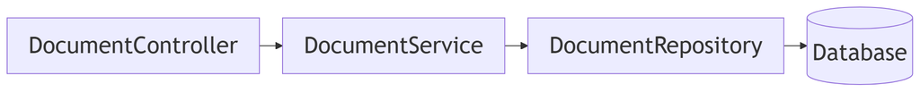

*Figure 4.1 — One request's path through the classes (simplified)*

*Text description:* Four boxes in a row, read left to right: `DocumentController`, `DocumentService`, `DocumentRepository` and the database. Each arrow means the class on the left hands work to the class on the right, and a request travels along the arrows from the web layer down to the data.

The controller receives the web request and asks the service to do the work; the service applies the rules and asks the repository for data; the repository talks to the database. Each arrow is a constructor parameter. Part II builds exactly this layering.

### 4.7 Packages, imports, and access levels

A large program has hundreds of classes. **Packages** group them, like folders. The first line of each file declares its package, and the folder layout matches it. `PageInfo` is in `com.example.securedocviewer.model`, so its file sits in `src/main/java/com/example/securedocviewer/model/`.

Table 4.2 shows the app's packages under `com.example.securedocviewer`.

Table 4.2 — The app's packages (book-m6-final)

| Package | Holds |
| --- | --- |
| `account` | Users, roles, the account service |
| `audit` | The audit trail |
| `config` | Settings read from `application.yml` |
| `controller` | The web endpoints |
| `document` | Documents, sharing, visibility |
| `exception` | The app's own error types |
| `model` | Plain data records such as `PageInfo` |
| `security` | Sign-in, sessions, throttling |
| `service` | Tile rendering, signing, watermarking |

To use a class from another package, you **import** it: `import java.util.List;` at the top of a file lets you write `List` instead of `java.util.List`. Classes in `java.lang`, such as `String`, need no import. Packages also let two classes share a name without clashing.

The reverse-domain name `com.example` is a convention that keeps package names unique across the world. The project uses the placeholder `example.com`.

Packages also matter for **access levels**, which decide who may use a class, field or method. Table 4.3 lists the four, with examples from the project.

Table 4.3 — Access levels

| Level | Written as | Who can use it | Example in the app |
| --- | --- | --- | --- |
| Public | `public` | Any code | `public class AppUser` |
| Protected | `protected` | The same package, and subclasses | `protected AppUser()` for the database library |
| Package-private | (nothing) | Only code in the same package | `final class FileOperations` in `service` |
| Private | `private` | Only the same class | the fields of `AppUser` |

`FileOperations` has no `public` in front of `class`, so only other classes in the `service` package can use it. That is a design choice: the file-moving helpers are an internal detail of tile handling, and hiding them stops other packages from depending on them. Make things as private as you can, and widen access only when there is a reason.

## Advanced tier: Annotations, design, and a real bug

*On a first read you can skip to "In this project"; Chapters 11 and 14 come back to annotations.*

### 4.8 Annotations: a first look

Look again at Listing 4.1. Lines that start with `@` are **annotations**: labels attached to code that tools read. `@Entity` tells the database library "this class maps to a table." `@Column(nullable = false, length = 64)` says the field maps to a column that cannot be empty and holds at most 64 characters. `@SpringBootApplication` in Listing 3.1 tells Spring where to start. `@Override` in Listing 4.9 is read by the compiler itself.

An annotation does not do anything by itself. A framework finds it, reads it, and acts. That is why the app's code can be so short: much behavior is declared with labels and carried out by libraries. Table 4.4 lists the ones you will meet most, and where each is taught.

Table 4.4 — Annotations you will meet

| Annotation | Meaning | Taught in |
| --- | --- | --- |
| `@Entity`, `@Column`, `@Id` | Map a class and its fields to a database table | Chapter 14 |
| `@RestController`, `@GetMapping`, `@PostMapping` | Turn a class and its methods into web endpoints | Chapter 12 |
| `@Component`, `@Service` | Let the framework create and inject this class | Chapter 11 |
| `@Override` | The compiler checks that this fulfills an interface or parent method | This chapter |

The cost of annotations is that behavior becomes less visible. If something happens that you cannot find in the code, look for an annotation. Parts II and III return to this often.

### 4.9 A note on inheritance and composition

You have seen `extends` twice: `interface DocumentRepository extends JpaRepository<...>` and, in Chapter 5, `class ResourceNotFoundException extends RuntimeException`. **Inheritance** means a new type takes everything an existing one has and adds to it. It is useful for a small set of cases, such as your own exception types, where you genuinely mean "is a kind of." For most other cases, the project prefers **composition**: a class *has* another object and uses it, as `RequestActors` has a `SessionKeys`. Composition keeps classes independent and easier to test. The app has almost no inheritance between its own classes, and this book teaches only what you have seen here.

### 4.10 A real incident: the demoted publisher who could still manage documents

Design choices in small objects can carry security weight. Recall `Viewer` from Listing 4.5: a record of a username and two booleans, `admin` and `publisher`, built from the sign-in. The record is immutable, which means those booleans are a snapshot of what the user could do at the moment of sign-in.

**The problem.** In the first version of the ownership rules, a document's owner could manage it. During the review of the fifth pull request, the technical-manager review (an AI review agent) found a gap. A publisher who had been demoted to reader no longer had the right to manage anything. Yet they could still manage the documents they owned, because ownership alone was enough.

**The fix.** Managing a document now requires both ownership and the publisher role (or being an administrator), and the rule lives in one small method, `canManage`. The reviews of the fifth pull request happened in stages called rounds, which Chapter 32 tells in full. In the fourth round, a second method, `currentRoles`, was added. Its comment states its purpose: to use the viewer's roles as they are in the database now, not as they were at sign-in. Both are shown here:

**Listing 4.12 — `DocumentService.java` (book-m6-final, excerpt: methods `currentRoles` and `canManage`)**

```java
    /** The viewer's roles as they are in the database now, not as they were at sign-in. */
    private Viewer currentRoles(Viewer viewer) {
        return users.findByUsername(viewer.username())
                .filter(AppUser::isEnabled)
                .map(user -> new Viewer(user.getUsername(), user.getRole() == Role.ADMIN,
                        user.getRole() == Role.ADMIN || user.getRole() == Role.PUBLISHER))
                .orElse(new Viewer(viewer.username(), false, false));
    }

    private static boolean canManage(Document document, Viewer viewer) {
        return viewer.admin()
                || (viewer.publisher() && document.getOwner().getUsername().equals(viewer.username()));
    }
```

*Path: `src/main/java/com/example/securedocviewer/document/DocumentService.java`*

Read `canManage`: an admin may manage anything; otherwise the viewer must be a publisher *and* the owner. Read `currentRoles`: look the user up again, keep them only if the account is still enabled, and build a fresh `Viewer` from their present role; if the account is gone or disabled, return a `Viewer` with no rights at all. Every step is one you now know: an `Optional` chain (Chapter 5), an enum comparison, a record constructor, a static method.

*Read now, revisit later.* Two pieces of syntax here belong to Chapter 5. First, `AppUser::isEnabled` is a short way to write "call `isEnabled` on the user", called a *method reference*. Second, the chain `.filter(...).map(...).orElse(...)` works on an `Optional`, a box that may hold a user or nothing. Read the chain as: look the user up; keep them only if the account is enabled; build a `Viewer` from their current role; if there is no such user, use a `Viewer` with no rights. The lesson does not depend on the syntax.

**The lesson.** An immutable record is safe against being changed, but it can still be *stale*. When a decision depends on facts that can change, such as a role, re-check them at the moment of the decision. The same principle runs through the app: access to tiles is re-checked on every tile request, so unsharing a document cuts off pages that are already open.

### 4.11 Common mistakes

**Forgetting `new`.** `Account a = Account("pub.one");` is an error; write `new Account("pub.one")`.

**`NullPointerException` on a field.** A field that you never set is `null` for objects (and `0` or `false` for numbers). Set it in the constructor.

**Calling an object's method on the class name.** `Account.recordFailure()` fails because the method belongs to an object. Call it on one: `a.recordFailure()`. Only `static` methods are called on the class, like `Viewer.of(...)`.

**Public fields.** They let any code break your rules, as Section 4.2 showed with `touch()`. Make fields `private`.

**Using `==` to compare objects.** For text and other objects, use `.equals`. Records already compare by value; ordinary classes compare by identity unless you write `equals`.

**A record with a setter.** Records have no setters. If you need change, you want a class, or you build a new record with the new values.

**Mismatched package and folder.** The compiler or build tool complains that a class is not found or in the wrong place. The `package` line must match the folder path under `src/main/java`.

**Missing import.** "cannot find symbol" on a class name usually means an `import` line is missing. Your editor can add it for you.

**Getter names for records.** A record's read method is `rows()`, not `getRows()`. Ordinary classes such as `AppUser` follow the `getX()` convention.

## In this project

- `account/AppUser.java`, `document/Document.java`: classes with private fields and rule-keeping setters.
- `model/PageInfo.java`, `model/SignedTilePayload.java`, `document/DocumentSummary.java`, `document/Viewer.java`, `audit/AuditEvent.java`: records.
- `account/Role.java`, `document/Visibility.java`, `audit/AuditEventType.java`: enums.
- `document/DocumentRepository.java`, `account/AppUserRepository.java`: interfaces implemented by Spring; `security/DatabaseUserDetailsService.java`: a class that implements an interface.
- `audit/RequestActors.java`, `security/KnownDevices.java`: constructor injection, and a swappable clock.
- `document/DocumentService.java`: `canManage` and `currentRoles`.

## Try it

### Exercise 4.1 ★ Class or record?

For each of these say whether you would write a class or a record, and why: a tile's `row` and `col`; an account whose password can change; the result of a search (a title and a page count).

*Solution:* Appendix C, Exercise 4.1.

### Exercise 4.2 ★ Write a record

Write a record `TileRef(int row, int col)`, create one for row 2, column 1, and print it. What does `toString` show? Run it with `java TileRefDemo.java`.

*Solution:* Appendix C, Exercise 4.2.

### Exercise 4.3 ★★ Add an enum

After Chapter 7 shows you how to get the project, open `Visibility.java`. Then write your own enum `TileStatus` with three values of your choice for a tile that is queued, ready, or failed. Use it in a `main` and compare a value with `==`. Work in a scratch folder, not in the repository.

*Solution:* Appendix C, Exercise 4.3.

### Exercise 4.4 ★★ A class that keeps a rule

Write a class `Counter` with a private `int count`, a method `increment()` that adds one but never goes above a maximum given to the constructor, and a getter. Show that a caller cannot push the count past the maximum.

*Solution:* Appendix C, Exercise 4.4.

### Exercise 4.5 ★★ Swap a part

Using Example 4.3 as a guide, write a method `describe(TileStore store)` that prints how many bytes `store.load("tile-0_0.png")` returns. Call it once with `DiskTileStore` and once with `FakeTileStore`. Explain what would have to change in `describe` to support a third store.

*Solution:* Appendix C, Exercise 4.5.

### Exercise 4.6 ★★★ Model a request

Design (on paper or in code) the small types for one audit event: an enum for the kind of event, a record for who did it, and a record for what it was about, following Listing 4.6 and `AuditEventType`. Add a static factory method for an event with no subject. Explain why you chose a record for each, and which fields you would allow to be `null`.

*Solution:* Appendix C, Exercise 4.6.

## Summary

- A class is a blueprint and an object is one instance; fields hold state and constructors set it up.
- Private fields with getters and setters hide the details, and a setter can keep a rule true; immutable data is easier to trust.
- Records are one-line immutable data classes that compare by value; enums are a closed list of values.
- Interfaces are promises; depending on them lets you swap and test parts, and constructor injection is how objects receive their collaborators.
- Packages organize code, imports bring names in, and four access levels decide who can use what.
- Annotations are labels that frameworks act on.
- An immutable snapshot can still be stale, so re-check facts that can change at the moment of the decision.

## Further reading

- *The Java Tutorials*, "Classes and Objects." https://docs.oracle.com/javase/tutorial/java/javaOO/index.html
- *The Java Tutorials*, "Interfaces and Inheritance." https://docs.oracle.com/javase/tutorial/java/IandI/index.html
- *The Java Language Specification*, Java SE 25 edition, "Records" and "Enum Classes." https://docs.oracle.com/javase/specs/

# Chapter 5: Collections, generics, lambdas, and exceptions

Programs rarely handle one value at a time. The app lists many documents, tracks many failed sign-ins, and stores many tiles. This chapter teaches how Java holds groups of values, how to process them concisely, and how to signal and handle failure. It finishes with time, which the app treats with unusual care, and with the few things that go wrong when many requests touch the same data at once.

## Learning objectives

By the end of this chapter, you will be able to:

- Choose between a list, a set, and a map, and loop over each.
- Read a generic type such as `Map<String, Deque<Instant>>`.
- Read a lambda and a short stream pipeline, and write a simple one.
- Explain why `Optional` exists and use `orElseThrow`.
- Throw, catch, and define an exception, and explain what `finally` is for.
- Explain what try-with-resources does.
- Explain why the app stores times in UTC, and why a shared map needs care.
- Diagnose the common collection and exception errors.

## Prerequisites

- Chapter 4: Classes, objects, records, and interfaces

## Beginner tier: Groups of values

### 5.1 Lists, sets and maps

A **collection** is an object that holds many values. Three kinds cover almost everything in this app.

- A **list** keeps items in order and allows duplicates. Example: the documents on a library page, newest first.
- A **set** keeps each item at most once and does not promise any order. Example: the users a document is shared with; sharing twice with the same user changes nothing.
- A **map** connects **keys** to **values**, like a dictionary. Each key appears at most once. (Unlike a printed dictionary, a map has no alphabetical order, and you can change its entries at any time.) Example: a username mapped to that user's recent failed sign-ins.

Figure 5.1 puts the three collections side by side, each with the place in the app that uses it.

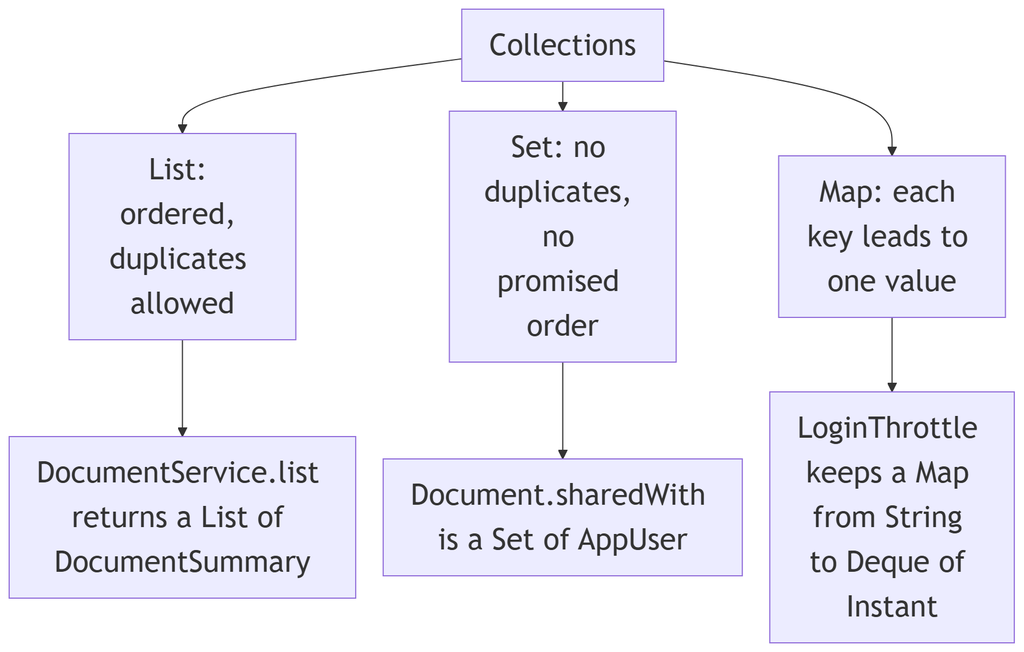

*Figure 5.1 — List, set and map, with the code that uses each*

*Text description:* A tree read top to bottom. A root box labeled Collections has three children, list, set and map, each with a one-line rule. Beneath each child is one real example from the app: a list of document summaries, a set of users a document is shared with, and a map from a key to a queue of timestamps.

The top row is the idea; the bottom row is the real code from `book-m6-final`. Ask one question to choose: do I need order (list), uniqueness (set), or lookup by a name (map)?

Example 5.1 shows all three, and the way to run it. (`var` lets the compiler work out the type from the right-hand side.)

**Example 5.1 — The three collections**

```java
import java.util.*;

public class Collections101 {
    public static void main(String[] args) {
        var pages = new ArrayList<String>();      // list
        pages.add("cover");
        pages.add("contents");
        System.out.println(pages.get(0));         // cover (counting starts at 0)

        var sharedWith = new HashSet<String>();   // set
        sharedWith.add("reader.one");
        sharedWith.add("reader.one");             // ignored: already there
        System.out.println(sharedWith.size());    // 1

        var failures = new HashMap<String, Integer>();   // map
        failures.put("pub.one", 2);
        System.out.println(failures.get("pub.one"));     // 2
    }
}
```

Save it as `Collections101.java` and run it with `java Collections101.java` (Chapter 3). Line by line: `import java.util.*;` brings in the collection classes. `new ArrayList<String>()` creates an empty list that holds text. `add` appends, `get(0)` reads the first item (indexes start at zero, as in Chapter 3), and `size()` counts. For the set, adding the same text twice leaves one item. For the map, `put(key, value)` stores and `get(key)` looks up.

The real app uses each. A document keeps its shares as `Set<AppUser> sharedWith = new HashSet<>()`, and the sign-in throttle keeps a map from a key to a queue of timestamps. The words `ArrayList`, `HashSet` and `HashMap` name particular implementations. What matters to a beginner is the kind of collection, and the interface types `List`, `Set` and `Map` (Chapter 4's interfaces) that you use when declaring a variable. Code that declares `List<String>` works with any list, which is the point of an interface.

### 5.2 Generics in plain words

What are the angle brackets in `ArrayList<String>`? They are a generic parameter: they say what type of thing the collection holds. A `List<String>` holds only text, and the compiler refuses to let you add a number. Without generics you would find out at runtime, with a crash, when the wrong kind of value came out of the list.

Read a generic type from the outside in. The throttle's field is `Map<String, Deque<Instant>>`:

- a map,
- whose keys are `String`,
- and whose values are `Deque<Instant>`, a **deque** (double-ended queue: you can add and remove at both ends) of `Instant` values, which are moments in time (Section 5.8).

That is: for each key, a queue of when the failures happened. Reading types like this is a skill you will use all through Parts II and III.

Two details save confusion. First, when you write `new HashMap<>()` the empty angle brackets, called the **diamond**, tell the compiler to copy the types from the left side, so you write them once. Second, generic collections hold objects, not the plain types of Chapter 3. The map in Example 5.1 uses `Integer`, the object form of `int`, and Java converts between them automatically (**boxing**). You write `Map<String, Integer>`, never `Map<String, int>`.

### 5.3 Looping over a collection

To visit every item, use the **for-each loop**. It reads "for each `p` in `pages`". You do not manage an index, so you cannot get it wrong.

**Example 5.2 — Walking a list and a map**

```java
import java.util.*;

public class Walk {
    public static void main(String[] args) {
        List<String> pages = List.of("cover", "contents", "chapter one");
        for (String p : pages) {
            System.out.println(p);
        }
        System.out.println(pages.contains("cover"));     // true

        Map<String, Integer> failures = new HashMap<>();
        failures.put("pub.one", 2);
        failures.put("reader.one", 0);
        for (Map.Entry<String, Integer> e : failures.entrySet()) {
            System.out.println(e.getKey() + " -> " + e.getValue());
        }
        int n = failures.getOrDefault("outsider.one", 0);
        System.out.println(n);                            // 0
    }
}
```

`List.of(...)` builds a list that cannot be changed afterward (an immutable list, as in Chapter 4); calling `add` on it throws an exception. A map is not directly loopable, so you loop over its **entries**, each holding a key and a value. `getOrDefault` answers a missing key with a fallback instead of `null`, which avoids a whole class of errors that Section 5.5 discusses. The order of a `HashMap`'s entries is not something to rely on: print it twice on two machines and the order may differ.

## Intermediate tier: Processing and failing

*On a first read you can skim this tier; Chapters 13 and 14 use these ideas again.*

### 5.4 Lambdas and streams

A **lambda** is a small unnamed method you can pass around. `u -> u.getUsername()` means "given `u`, produce `u.getUsername()`". A **stream** is a pipeline that processes a collection step by step: filter some items, transform others, collect a result. Build it up one step at a time.

**Example 5.3 — Filter and transform**

```java
import java.util.List;

public class StreamDemo {
    public static void main(String[] args) {
        List<String> names = List.of("pub.one", "reader.one", "outsider.one");
        List<String> shortNames = names.stream()
                .filter(n -> n.length() < 10)
                .map(n -> n.toUpperCase())
                .toList();
        System.out.println(shortNames);   // [PUB.ONE]
    }
}
```

`names.stream()` starts the pipeline. `filter` keeps items for which the lambda is true: only `pub.one` is shorter than 10 characters. `map` transforms each remaining item, here to uppercase. `toList()` ends the pipeline and returns a new list. The original list is untouched, which is a useful property: a pipeline describes a new result and never edits its input.

Two more pieces of vocabulary appear in the app. A **method reference** is a short form of a lambda that only calls one method: `AppUser::getUsername` means the same as `u -> u.getUsername()`. And `anyMatch` asks "is at least one item true for this?", stopping at the first yes. The app's permission check uses it.

**Listing 5.1 — `DocumentService.java` (book-m6-final, excerpt: method `canView`)**

```java
    private static boolean canView(Document document, Viewer viewer) {
        return viewer.admin()
                || document.getVisibility() == Visibility.EVERYONE
                || document.getOwner().getUsername().equals(viewer.username())
                || document.getSharedWith().stream().anyMatch(u -> u.getUsername().equals(viewer.username()));
    }
```

*Path: `src/main/java/com/example/securedocviewer/document/DocumentService.java`*

Read it as a sentence. A viewer may view a document if they are an admin, or the document's visibility is `EVERYONE`, or they are the owner, or some user in the document's shares has their username. The `||` operator (Chapter 3) stops at the first true part, so the cheap checks run before the search through the shares. Here is a longer pipeline that turns stored documents into rows for the library page.

**Listing 5.2 — `DocumentService.java` (book-m6-final, excerpt: method `list`)**

```java
    public List<DocumentSummary> list(Viewer viewer) {
        return tx.execute(status -> {
            List<Document> visible = viewer.admin()
                    ? documents.findAllWithOwner()
                    : documents.findVisibleTo(viewer.username(), Visibility.EVERYONE);
            return visible.stream().map(d -> summary(d, viewer)).toList();
        });
    }
```

*Path: `src/main/java/com/example/securedocviewer/document/DocumentService.java`*

Three things to notice. The `? :` is a compact `if`: administrators get every document, everyone else only those visible to them. `visible.stream().map(d -> summary(d, viewer)).toList()` converts each `Document` to a `DocumentSummary`. And `status -> { ... }` is a lambda handed to `tx.execute`, which runs it inside a database transaction (Chapter 9 and Chapter 14). We simplify here: streams have many more operations, but the app needs mostly `map`, `filter`, `anyMatch`, and `toList`.

Figure 5.2 shows the pipeline inside `list` as a picture: data flows left to right, and each step produces a new value without changing the one before it.

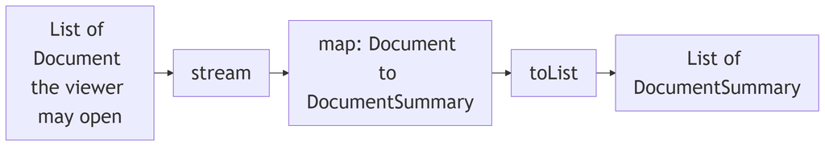

*Figure 5.2 — The stream pipeline in DocumentService.list*

*Text description:* Five boxes in a row, read left to right. A list of documents the viewer may open goes through `stream`, then a step that converts each document to a summary, then `toList`, and ends as a list of summaries. Notice that the starting list is never changed; each step produces something new.

Read it against Listing 5.2: `visible.stream().map(d -> summary(d, viewer)).toList()` is these three boxes in a row.

#### Why streams and not loops?

Everything a stream does you could write with a for-each loop and a temporary list. The stream version says *what* you want, not *how* to build it, and that reads faster once you know the vocabulary. It is not always better. For a loop with several exits or lots of changing state, a plain loop is clearer, and the project uses both (Listing 3.2's nested loop is a good example of a loop that would be worse as a stream).

### 5.5 Optional and the trouble with null

Java has a special value, `null`, meaning "no object here." Calling a method on `null` crashes with a `NullPointerException`, so forgetting to check is a common bug. **Optional** is a box that is either empty or holds one value. A method that returns `Optional<AppUser>` tells the caller "there may be no user; decide what to do", and the compiler makes sure the caller sees that.

The user repository declares exactly that, and callers decide.

**Listing 5.3 — `AppUserRepository.java` (book-m6-final, excerpt)**

```java
    Optional<AppUser> findByUsername(String username);
```

*Path: `src/main/java/com/example/securedocviewer/account/AppUserRepository.java`*

**Listing 5.4 — `UserAccountService.java` (book-m6-final, excerpt: method `require`)**

```java
    private AppUser require(String rawUsername) {
        String username = normalizeUsername(rawUsername);
        return repository.findByUsername(username)
                .orElseThrow(() -> new ResourceNotFoundException("No such user: " + username));
    }
```

*Path: `src/main/java/com/example/securedocviewer/account/UserAccountService.java`*

`orElseThrow` means: give me the value, or if the box is empty, throw this exception. The `() -> new ...` lambda builds the exception only when needed. Example 5.4 is a small program you can run to see two common ways of opening the box, and the way of making one.

**Example 5.4 — Opening an Optional**

```java
import java.util.Map;
import java.util.Optional;

public class Opt {
    static Optional<String> roleOf(Map<String, String> roles, String user) {
        return Optional.ofNullable(roles.get(user));
    }

    public static void main(String[] args) {
        Map<String, String> roles = Map.of("pub.one", "PUBLISHER");
        System.out.println(roleOf(roles, "pub.one").orElse("none"));      // PUBLISHER
        System.out.println(roleOf(roles, "nobody").orElse("none"));       // none
        try {
            roleOf(roles, "nobody")
                    .orElseThrow(() -> new IllegalStateException("No such user: nobody"));
        } catch (IllegalStateException e) {
            System.out.println(e.getMessage());                            // No such user: nobody
        }
    }
}
```

`Optional.ofNullable` wraps a value that might be `null` (a map's `get` returns `null` for a missing key). `orElse` supplies a fallback. `orElseThrow` turns "nothing" into an error, which is what you want when the caller cannot continue without the value.

### 5.6 Exceptions: throwing, catching, custom types

An exception is an object that represents a failure. When code throws one, normal execution stops and the exception travels up the chain of callers (Chapter 3's stack trace) until something **catches** it. If nothing does, the program or the request ends with the error.

**Example 5.5 — Catching**

```java
public class CatchDemo {
    static int tileCount(int lengthPx, int tileSize) {
        if (lengthPx <= 0 || tileSize <= 0) {
            throw new IllegalArgumentException("lengthPx and tileSize must both be positive");
        }
        return (lengthPx + tileSize - 1) / tileSize;
    }

    public static void main(String[] args) {
        try {
            int cols = tileCount(0, 512);
            System.out.println(cols);
        } catch (IllegalArgumentException e) {
            System.out.println("Bad input: " + e.getMessage());
        }
    }
}
```

The method is a copy of the app's `TileGrid.tileCount` from Chapter 3, so the example stands alone. The `println(cols)` line never runs: the exception jumps straight to the `catch` block.

Add a third part when something must happen whether or not an error occurred. The **finally** block always runs, on success and on failure alike.

**Example 5.6 — try, catch, and finally**

```java
public class Finally {
    static int parse(String text) {
        try {
            return Integer.parseInt(text);
        } catch (NumberFormatException e) {
            return -1;
        } finally {
            System.out.println("parsed " + text);
        }
    }

    public static void main(String[] args) {
        System.out.println(parse("12"));   // parsed 12, then 12
        System.out.println(parse("x"));    // parsed x, then -1
    }
}
```

Java sorts exceptions into a family tree. Those that extend `RuntimeException` are **unchecked exceptions**: the compiler does not force you to catch them. `IllegalArgumentException` and `NumberFormatException` are unchecked. Others, such as `IOException` (which file operations throw), are **checked exceptions**: a method that can throw one must either catch it or declare `throws IOException`, which you will see in `DocumentController.upload` in Listing 5.6. The app defines its own exceptions as unchecked, so business code can throw them without cluttering every method signature.

The app defines its own exception types so that each failure has a meaning. The smallest is one line of substance.

**Listing 5.5 — `ResourceNotFoundException.java` (book-m6-final)**

```java
package com.example.securedocviewer.exception;

/** Mapped to 404. */
public class ResourceNotFoundException extends RuntimeException {
    public ResourceNotFoundException(String message) {
        super(message);
    }
}
```

*Path: `src/main/java/com/example/securedocviewer/exception/ResourceNotFoundException.java`*

`extends RuntimeException` means "is a kind of `RuntimeException`" (inheritance: the new class gets everything the old one has). `super(message)` passes the message to it. The comment says where it ends up: a single class, `GlobalExceptionHandler`, catches these and turns each into an HTTP status such as `404 Not Found`. Chapter 8 taught status codes and Chapter 13 shows the handler. The design choice is that business code throws a meaningful exception and one central place decides what the user sees. The project has eleven such types, one for each kind of refusal: not found, forbidden, bad request, too many requests, and so on. Figure 5.3 follows one exception from where it is thrown to what the user sees.

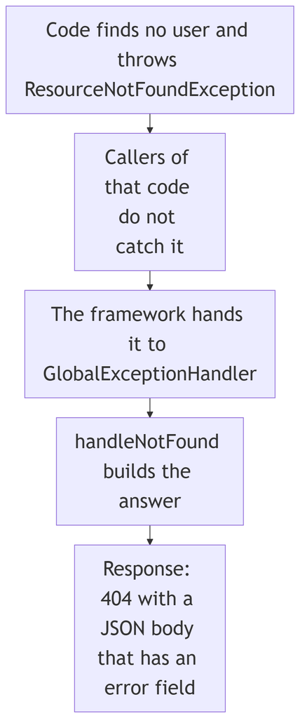

*Figure 5.3 — From a thrown exception to a 404 response*

*Text description:* Five boxes in a column, read top to bottom. Code that finds no user throws an exception, the callers of that code do not catch it, the framework hands it to `GlobalExceptionHandler`, `handleNotFound` builds the answer, and the response is a 404 with a JSON body containing an `error` field.

The business code never mentions HTTP. It throws a meaningful exception, and one central class turns it into a status code (Chapter 13 shows the class in full).

A related security rule shows in `ForbiddenException`'s comment: resources a user may not see at all are reported as 404, not 403, "so their existence isn't revealed."

### 5.7 try-with-resources and files

Files, network connections, and database connections must be **closed** after use, or the program leaks them until it runs out. **Try-with-resources** closes them automatically, even if an error happens.

**Listing 5.6 — `DocumentController.java` (book-m6-final, excerpt: method `upload`)**

```java
        try (var in = file.getInputStream()) {
            return documents.upload(title, file.getOriginalFilename(), in, visibility,
                    Viewer.of(authentication), actors.of(request, authentication));
        }
```

*Path: `src/main/java/com/example/securedocviewer/controller/DocumentController.java`*

The resource in parentheses, the uploaded file's stream of bytes, is closed when the block ends, whether it ends normally or by an exception. Without this, one failed upload could leave a file open until the server restarted. For files on disk Java offers `Path` (a file address) and `Files` (operations on it). `FileOperations.java` uses `Files.move` to rename a folder of tiles in one step, and retries when Windows briefly locks a file. Chapter 17 covers files in the app.

### 5.8 Time: Instant, UTC, and why the app uses it

An **Instant** is a single point on the timeline, independent of time zones. **UTC** (Coordinated Universal Time) is the world's reference time, with no daylight-saving changes. Ask for the current one with `Instant.now()`. A local time such as "10:30 in Kolkata" names different instants depending on the zone, but an instant is the same everywhere.

**Example 5.7 — Instants and seconds**

```java
import java.time.Duration;
import java.time.Instant;

public class Clock101 {
    public static void main(String[] args) {
        Instant issued = Instant.parse("2026-09-19T00:00:00Z");
        System.out.println(issued.getEpochSecond());          // 1789776000
        Instant expires = issued.plus(Duration.ofSeconds(120));
        System.out.println(expires);                           // 2026-09-19T00:02:00Z
        System.out.println(expires.isBefore(issued));          // false
    }
}
```

`Instant.parse` reads a timestamp; the trailing `Z` means UTC. `getEpochSecond()` gives the **epoch seconds**: the number of seconds since midnight UTC on January 1, 1970, a plain number, which is how the app stores a token's expiry (`expiresAtEpochSeconds` in Listing 4.4). `Duration` is a length of time, and `plus` moves an instant forward. The app's signed tile URLs live 120 seconds (Chapter 1), so this example computes exactly such an expiry.

The app also stores every database timestamp as UTC. Why? A server in a Docker container (Chapter 10) runs in UTC, while a developer's laptop may run in local time. If they disagreed about what "9:00" means, the same stored value would be read as different moments. Two settings in `application.yml` fix that: `connectionTimeZone=UTC` in the database connection address, and `hibernate.jdbc.time_zone: UTC` for Hibernate, the library that moves Java objects in and out of the database (Chapter 14). Watermarks also show a UTC timestamp for the same reason.

## Advanced tier: When many requests share data

This tier is a first look at ideas that professional programmers spend years mastering: several requests running at once, and what an error handler should tell a user. It is fine to read it quickly for the main ideas, or to skip it and return after Part II, when the app's web layer makes these problems concrete. Nothing in Chapters 6 to 10 depends on it, except the plain facts that the app stores time in UTC and that error messages must not leak internals.

### 5.9 Collections that many requests share

A web server handles many requests at the same time, each on its own **thread**: a path of execution inside the program. Code is **thread-safe** if it stays correct when several threads use it at once. An **atomic** step is one that cannot be interrupted halfway: it happens completely or not at all, and no other thread can see it half done. Two threads can touch the same collection in the same instant, and an ordinary `HashMap` or `ArrayDeque` breaks if they do, sometimes corrupting its contents without any error message.

Java offers collections designed for this. `ConcurrentHashMap` is a map that many threads can use safely. The app's sign-in throttle keeps one of them, and inside it a queue of failure times for each key. The code that adds and expires those times shows both tools: the safe map, and a **synchronized** block, a Java feature that lets only one thread at a time change one queue.

**Listing 5.7 — `LoginThrottle.java` (book-m6-final, excerpt: methods `append` and `prune`)**

```java
    private void append(String key, Instant at) {
        Deque<Instant> attempts = failures.computeIfAbsent(key, k -> new ArrayDeque<>());
        synchronized (attempts) {
            attempts.addLast(at);
        }
    }

    private static void prune(Deque<Instant> attempts, Instant cutoff) {
        while (!attempts.isEmpty() && attempts.peekFirst().isBefore(cutoff)) {
            attempts.pollFirst();
        }
    }
```

*Path: `src/main/java/com/example/securedocviewer/security/LoginThrottle.java`*

`computeIfAbsent(key, ...)` means "return the queue for this key, creating an empty one first if there is none," as one safe step. `synchronized (attempts)` makes other threads wait if they want the same queue. (In the real class, `prune` is only ever called from inside another `synchronized (attempts)` block, in the method `lockedFor`, so it is protected there too.) In `prune`, the queue holds failure times in order, oldest first. So `peekFirst` looks at the oldest, and `pollFirst` removes it while it is older than the cutoff. What is left is exactly the failures inside the time window. You can try the same idea in a few lines.

**Example 5.8 — A sliding window of failures**

```java
import java.time.Duration;
import java.time.Instant;
import java.util.ArrayDeque;
import java.util.Deque;

public class Window {
    public static void main(String[] args) {
        Deque<Instant> failures = new ArrayDeque<>();
        Instant now = Instant.parse("2026-01-01T10:00:00Z");
        failures.addLast(now.minusSeconds(1000));
        failures.addLast(now.minusSeconds(100));
        failures.addLast(now.minusSeconds(10));

        Instant cutoff = now.minus(Duration.ofMinutes(15));   // 900 seconds ago
        while (!failures.isEmpty() && failures.peekFirst().isBefore(cutoff)) {
            failures.pollFirst();
        }
        System.out.println(failures.size());                   // 2
    }
}
```

The failure 1,000 seconds ago is older than the 900-second window, so it is dropped; two remain. The app's window is 15 minutes, and its limits are five failures per account and address, 20 per address and 20 per account from unrecognized devices.

#### A real incident: nine simultaneous wrong passwords

Care with shared data was not theoretical. In the last review rounds, the technical-manager reviewer (an AI review agent) probed the sign-in with nine wrong passwords sent at the same moment for one account from one address, against a limit of five. All nine were answered as "wrong password" (401), and only the next single attempt was refused (429). The cause was that the code checked the limit first, then verified the password (which takes about 100 milliseconds), then recorded the failure, with nothing tying the three steps together, so many requests slipped through in the gap. The fix reserved the attempt atomically before checking the password: count first, give the count back on success. With the fix exactly five got through. The lesson generalizes: a check and the update it depends on must happen as one step, or concurrent requests will pass the check together.

### 5.10 A real incident with time: the audit rows from the future

Time bugs are the same kind of problem seen through a clock. Late in development, the audit log showed events with future times. The cause was a mismatch between two backends that shared one database. The developer's backend ran in the Asia/Kolkata time zone and wrote local time. The Docker backend wrote UTC. So the two sets of rows disagreed by five and a half hours. The product-owner reviewer (also an AI review agent) found it. The fix pinned the database connection and Hibernate to UTC and made the admin audit view show UTC, to match the watermark and the CSV export (CSV, comma-separated values, is a plain-text table format that spreadsheets open). A test now stores timestamps and checks them against a MySQL server set to a different time zone. The lesson: store instants in one zone and convert only when showing them to a person.

### 5.11 Exceptions at the edge: one more incident

Where exceptions end up matters as much as where they start. Here is the handler of last resort in the app.

**Listing 5.8 — `GlobalExceptionHandler.java` (book-m6-final, excerpt: method `handleUnexpected`)**

```java
    /** Last resort: never leak internals, but make the failure traceable in the log. */
    @ExceptionHandler(Exception.class)
    public ResponseEntity<Map<String, String>> handleUnexpected(Exception e) {
        String reference = UUID.randomUUID().toString().substring(0, 8);
        log.error("Unhandled error, reference {}", reference, e);
        return error(HttpStatus.INTERNAL_SERVER_ERROR,
                "Something went wrong on our side. Reference: " + reference + ".");
    }
```

*Path: `src/main/java/com/example/securedocviewer/controller/GlobalExceptionHandler.java`*

`@ExceptionHandler(Exception.class)` says "catch any exception nobody else handled." (`ResponseEntity` is the framework's object for a whole web response, a status plus a body, which Chapter 8 teaches; for now read the method as "build a 500 answer.") The method makes a short random reference. It writes the full exception to the log, with that reference. The log is the server's running record of what happened, a file or stream that developers read. Finally, the method returns a message to the user that contains only the reference. The user never sees a stack trace, file paths or SQL, which would help an attacker. Yet if the user reports the reference, a developer can find the exact log entry.

This handler earned its place. Before a fix, creating a user with a 100-character password returned a plain 500 with a reference. The validation allowed passwords of 12 to 128 characters, but the password hashing (BCrypt, Chapter 15) rejects more than 72 **bytes**, and a character can be more than one byte: 30 emoji can exceed 72 bytes. The fix checked the UTF-8 byte length and added a test. The lesson from the reviewer's note: characters are not bytes. And the handler did its job even then, by turning a crash into a traceable reference.

### 5.12 Common mistakes

**`NullPointerException`.** You called a method on a value that was `null`. Read the stack trace's first line for the exact line, then ask where the value should have come from. Prefer methods that return `Optional` or a default (`getOrDefault`).

**`UnsupportedOperationException` when you call `add`.** The list came from `List.of(...)`, `Map.of(...)` or `.toList()`, which are immutable. Copy it into a new `ArrayList` if you need to change it.

**`ConcurrentModificationException`.** You added or removed items from a collection while a for-each loop was walking it. Collect the changes and apply them after the loop, or use `removeIf`.

**Comparing text with `==`.** It compares whether two variables refer to the same object, not the same characters. Use `.equals` (Chapter 3).

**Catching too much.** `catch (Exception e)` at the wrong place hides bugs. Catch the specific exceptions you can handle, and let others travel to the central handler.

**Swallowing an exception.** An empty `catch` block hides a failure completely. At least log it, or rethrow.

**Forgetting to close a resource.** Use try-with-resources whenever you open a stream, connection or file.

## In this project

- `document/Document.java`, `security/LoginThrottle.java`: sets, maps and deques.
- `document/DocumentService.java`: streams, lambdas, `anyMatch` and `orElseThrow`.
- `exception/`: eleven custom exception types.
- `controller/GlobalExceptionHandler.java`: one place that turns exceptions into responses.
- `service/FileOperations.java`: file moves with retries.
- `service/SignedUrlService.java`: expiry as epoch seconds.

## Try it

### Exercise 5.1 ★ Pick the collection

For each, choose list, set or map: the pages of a document in order; the usernames allowed to open a document; each username with its role.

*Solution:* Appendix C, Exercise 5.1.

### Exercise 5.2 ★ Stream it

Given `List.of(1275, 1650, 512, 300)` of pixel lengths, write a stream that keeps the values above 512 and prints how many tiles each needs, using the ceiling formula from Chapter 3.

*Solution:* Appendix C, Exercise 5.2.

### Exercise 5.3 ★★ Throw and catch

Write a method `tileCount` that throws `IllegalArgumentException` on a non-positive input, and a `main` that catches it and prints the message. Then define your own exception `PageOutOfRange` and throw it instead.

*Solution:* Appendix C, Exercise 5.3.

### Exercise 5.4 ★★ Look up a user

Write a method `findRole(Map<String, String> roles, String username)` that returns `Optional<String>`. In `main`, print the role for a known user with `orElse`, and for an unknown user throw `IllegalStateException` with `orElseThrow`. Catch it and print the message.

*Solution:* Appendix C, Exercise 5.4.

### Exercise 5.5 ★★★ Build a small throttle

Write a class `MiniThrottle` with a method `boolean allow(String user, Instant now)` that allows at most three calls per user in any 60-second window. Keep a `Map<String, Deque<Instant>>`, prune old entries as in Example 5.8, and test it with instants you choose. Then explain which line would need `synchronized` if many threads called `allow` at once.

*Solution:* Appendix C, Exercise 5.5.

## Summary

- Lists keep order, sets keep uniqueness, maps connect keys to values; generics say what they hold, and for-each loops walk them.
- Lambdas and streams process collections in short pipelines; method references and `anyMatch` shorten common cases.
- `Optional` makes "maybe nothing" explicit; `orElseThrow` turns nothing into an error.
- Custom exceptions give failures meaning, and one central handler decides what users see, without leaking internals.
- Try-with-resources closes what you open; `finally` always runs.
- The app stores times as UTC instants, and shared collections need thread-safe types and atomic check-and-update steps.

## Further reading

- *The Java Tutorials*, "Collections." https://docs.oracle.com/javase/tutorial/collections/index.html
- *The Java Tutorials*, "Exceptions." https://docs.oracle.com/javase/tutorial/essential/exceptions/index.html
- *The Java Tutorials*, "Date Time." https://docs.oracle.com/javase/tutorial/datetime/index.html
- *Java Platform SE 25 API*, `java.time.Instant`. https://docs.oracle.com/en/java/javase/25/docs/api/

# Chapter 6: Maven and the shape of a project

Chapter 3 compiled one file by hand. The Secure Document Viewer has 84 Java files (tests included) and depends on many libraries written by other people. Nobody compiles that by hand. This chapter teaches Maven, the tool that downloads the libraries, compiles the code, runs the tests, and packages the result, and shows where every file in the project belongs. By the end you will be able to build the whole backend with one command and read the file that describes it.

## Learning objectives

By the end of this chapter, you will be able to:

- Explain what a build tool does and why the project needs one.
- Run the compile, test, package, and verify steps and say what each produces.
- Read `pom.xml` and say what each section is for.
- Explain what a dependency is, where Maven finds it, and what a scope does.
- Explain why the project runs Maven through `mvnw` and pins its versions.
- Diagnose the most common build failures.
- Say where source code, tests and settings live in the project.

## Prerequisites

- Chapter 3: Your first Java program
- Chapter 4: Classes, objects, records, and interfaces

## Beginner tier: What a build tool does

### 6.1 What a build tool does

To turn source code into a running application you must do several things in the right order. You fetch the libraries the code uses. You compile every file. You run the tests to check that nothing is broken. Finally you bundle the result into one file that can be started. Together these steps are called a **build**.

Doing a build by hand is slow, and it is error-prone. You might forget to download one library, or compile files in an order that fails. Worse, two people would do it slightly differently, and then the app would work on one machine and not the other.

A **build tool** does the build from a written description, the same way every time, on every machine. **Maven** is the build tool for this project. You describe the project once in a file called `pom.xml` (POM stands for Project Object Model), and Maven follows the description. The description says *what* the project is and which libraries it uses. It does not list the compile steps, because Maven already knows them. That is a deliberate design, and Section 6.9 returns to it.

**Analogy.** Maven is a recipe-following kitchen assistant: you hand over a recipe and it fetches the ingredients and cooks the dish in a fixed order.

**Where the analogy breaks down:** in two places. First, the ingredients here are other people's code, which can carry security flaws; Section 6.11 and Chapter 36 cover how the project watches for that. Second, a kitchen assistant improvises when something is missing, while Maven stops with an error and tells you what it could not find.

### 6.2 A first build, step by step

Before reading the description file, run the build once and watch what happens. You need Java 25 installed (Chapter 3) and a copy of the project (Step 7 of Setting up your machine clones it; Chapter 7 explains what that does). Open a terminal in the project folder, the one that contains `pom.xml`.

First, check that Java is the right version, because Maven uses whichever Java it finds:

```bash
java -version
```

You should see something like this, with a version that begins with 25:

```
openjdk version "25" ...
```

Now ask Maven, through the wrapper script that Section 6.7 explains, to print its own version:

```bash
./mvnw -v
```

The first time you run this, the script downloads Maven itself, which takes a moment. Afterwards you should see something like this:

```
Apache Maven 3.9.16 ...
Java version: 25 ...
```

Now compile the code:

```bash
./mvnw compile
```

On the first run, the terminal fills with lines that begin with `Downloading from central:`. Maven is fetching the libraries listed in `pom.xml`, and the libraries those libraries need, and storing them in a cache folder on your computer (by default `.m2/repository` inside your home folder). Later builds reuse the cache and print far less. When the build works, the last lines say `BUILD SUCCESS`.

Look at what appeared in the project folder:

```bash
ls target
```

A new folder named `target` holds the compiled `.class` files (the bytecode from Chapter 3) under `target/classes`. Everything Maven produces goes in `target`. Because you can always regenerate it, the project's `.gitignore` excludes it from Git (Chapter 7). If a build ever behaves strangely, delete the folder with `./mvnw clean` and build again; the word `clean` means "remove `target`".

You have now run a **phase** of Maven's lifecycle, a named step in a fixed sequence. Section 6.8 lists the sequence. First we read the file that told Maven what to do.

### 6.3 `pom.xml` line by line

Here is the top of the project's file.

**Listing 6.1 — `pom.xml` (book-m6-final, excerpt: the project's identity)**

```xml
    <parent>
        <groupId>org.springframework.boot</groupId>
        <artifactId>spring-boot-starter-parent</artifactId>
        <version>4.1.1</version>
        <relativePath/>
    </parent>

    <groupId>com.example</groupId>
    <artifactId>secure-doc-viewer</artifactId>
    <version>0.1.0</version>
    <name>secure-doc-viewer</name>
```

*Path: `pom.xml`*

Every Maven project or library is identified by three values, its **coordinates**. The `groupId` says who made it, written in the reverse-domain style from Chapter 4. The `artifactId` is its name. The `version` says which release it is. This project is `com.example:secure-doc-viewer:0.1.0`. Anyone in the world can name a library by its coordinates, and Maven can find exactly that release.

The `<parent>` block says "start from the settings of `spring-boot-starter-parent`, version 4.1.1". A **parent** POM supplies sensible defaults, and one of them matters a great deal: a tested list of matching library versions. That is why most dependencies later in the file have no version number. The parent chooses one that is known to work with the others. The empty `<relativePath/>` tag tells Maven to fetch the parent from the internet rather than look for it in a neighboring folder.

Spring Boot is the framework Part II teaches: a large library that supplies the structure of a web application, so you write only the parts specific to yours. Here you only need to know that it is also the source of the version list.

Next come the properties.

**Listing 6.2 — `pom.xml` (book-m6-final, excerpt: properties)**

```xml
    <properties>
        <java.version>25</java.version>
        <pdfbox.version>3.0.8</pdfbox.version>
                <tomcat.version>11.0.26</tomcat.version>
    </properties>
```

*Path: `pom.xml`*

### 6.4 Dependencies and where they come from

A **dependency** is a library your code uses. Instead of copying its files into the project, you name it by its coordinates, and Maven downloads it from **Maven Central**, a public repository of Java libraries, into the cache you saw in Section 6.2.

**Listing 6.3 — `pom.xml` (book-m6-final, excerpt: three dependencies taken from different places in the file, shown in file order)**

```xml
        <dependency>
            <groupId>org.springframework.boot</groupId>
            <artifactId>spring-boot-starter-webmvc</artifactId>
        </dependency>
        <dependency>
            <groupId>com.mysql</groupId>
            <artifactId>mysql-connector-j</artifactId>
            <scope>runtime</scope>
        </dependency>
        <dependency>
            <groupId>org.apache.pdfbox</groupId>
            <artifactId>pdfbox</artifactId>
            <version>${pdfbox.version}</version>
        </dependency>
```

*Path: `pom.xml`*

Reading them one at a time:

- `spring-boot-starter-webmvc` is a **starter**, a bundle that pulls in everything needed to build web endpoints. It has no version because the parent supplies one. The file's own comment notes that Spring Boot 4 splits the older all-in-one starters into focused ones.
- `pdfbox` has an explicit version, written `${pdfbox.version}`. The dollar sign and braces mean "insert the value of the property named `pdfbox.version`", which Listing 6.2 defined as 3.0.8. The parent does not manage this library, so the project chooses its version.
- `mysql-connector-j` is the driver that lets Java talk to MySQL. Its **scope** is `runtime`.

Table 6.1 — Dependency scopes used in this project

| Scope | Available when | Example in this project |
| --- | --- | --- |
| (none, the default) | Compiling, testing, and running | `pdfbox` |
| `runtime` | Testing and running, but not compiling | `mysql-connector-j` |
| `test` | Only while running tests | `h2`, `spring-boot-starter-test` |

The `runtime` scope for the MySQL driver is a small discipline with a purpose. Your own code never mentions a MySQL class directly; it talks to a general database interface, and the driver is plugged in when the program runs. Marking it `runtime` stops you from accidentally writing code that depends on a specific database.

#### Dependencies of dependencies

When you name `pdfbox`, you get more than one file. PDFBox itself depends on other libraries, and those depend on others. Maven follows the chain and downloads them all. These are **transitive dependencies**: the ones you did not list, but that arrive because something you listed needs them. The `spring-boot-starter-webmvc` starter is mostly a list of transitive dependencies, which is exactly why it is convenient.

You can see the full tree. This command prints every dependency, indented under the one that brought it in:

```bash
./mvnw dependency:tree
```

The output is long, and that is instructive: a project that names about twenty dependencies ends up with many more libraries on its path. Every one is code you trust, which matters for security (Section 6.11).

#### Why so many dependencies?

Each direct dependency does one job the project would not write itself: PDF rendering (`pdfbox`), the database (`spring-boot-starter-data-jpa`, Flyway and the MySQL driver), security, validation, and metrics. Writing a PDF renderer from scratch would take years and be worse. Using a well-tested library is the right trade, provided you keep the list short and watch it for known flaws. The project does both, and Chapter 36 shows how.

## Intermediate tier: Running Maven

*On a first read you can skim this tier and return to it when you first run a build.*

### 6.5 Test dependencies

Some libraries exist only to check the app, not to run it. They carry `<scope>test</scope>`, so they are used while tests run and never enter the packaged application. Here are three of them from the final `pom.xml`.

**Listing 6.4 — `pom.xml` (book-m6-final, excerpt: test dependencies)**

```xml
        <dependency>
            <groupId>org.springframework.boot</groupId>
            <artifactId>spring-boot-starter-test</artifactId>
            <scope>test</scope>
        </dependency>
        <dependency>
            <groupId>com.h2database</groupId>
            <artifactId>h2</artifactId>
            <scope>test</scope>
        </dependency>
                <dependency>
            <groupId>org.testcontainers</groupId>
            <artifactId>testcontainers-mysql</artifactId>
            <scope>test</scope>
        </dependency>
```

*Path: `pom.xml`*

`spring-boot-starter-test` is the starter that brings the testing tools (Chapter 18 teaches them). `h2` is a small database that lives entirely in memory, so most tests can exercise database code without needing MySQL running. `testcontainers-mysql` goes further: it starts a real MySQL in a Docker container (Chapter 10) for one test class. The comment in the file records that this test is skipped when Docker is not available, so a machine without Docker can still run the rest of the tests.

The pairing shows a real trade-off. Tests against the small in-memory database are fast and need nothing installed, but that database is not MySQL and can behave differently. The Testcontainers test is slower but faithful. The project keeps both: fast tests for everyday feedback, one faithful test as a check.

### 6.6 What the Spring Boot plugin adds

Maven does its work through **plugins**, small programs it runs at each step. Compiling is done by a plugin, and so is running tests. The `<build>` section of the `pom.xml` names the one plugin this project adds beyond the defaults.

**Listing 6.5 — `pom.xml` (book-m6-final, excerpt: the build section)**

```xml
    <build>
        <finalName>secure-doc-viewer</finalName>
        <plugins>
            <plugin>
                <groupId>org.springframework.boot</groupId>
                <artifactId>spring-boot-maven-plugin</artifactId>
            </plugin>
        </plugins>
    </build>
```

*Path: `pom.xml`*

`<finalName>` sets the name of the file Maven produces: `secure-doc-viewer`, plus the extension `.jar`. Without it, the name would include the version, `secure-doc-viewer-0.1.0.jar`, and every script that mentions the file would have to change at each release.

A **JAR** (Java ARchive) is a zip file of compiled classes. An ordinary JAR contains only your own classes, and running it also requires all the libraries. The Spring Boot plugin changes that. It repackages the JAR so that it also holds every library it needs and a small launcher. The result is an **executable JAR**: one file that holds the app, its libraries and even the web server, so you start the whole application with a single command, with no separate server to install.

You can look inside after a build (Section 6.8 shows how to make one):

```bash
jar tf target/secure-doc-viewer.jar
```

`jar tf` lists the files in the archive. You should see something like this, and much more of the same:

```
META-INF/MANIFEST.MF
BOOT-INF/classes/com/example/securedocviewer/SecureDocViewerApplication.class
BOOT-INF/lib/pdfbox-3.0.8.jar
...
```

The application's own classes live under `BOOT-INF/classes` and every library sits as a nested JAR under `BOOT-INF/lib`. Notice that the PDFBox filename carries the version from Listing 6.2.

### 6.7 The Maven wrapper (`mvnw`) and why it pins the version

Different Maven versions can behave differently. If you had Maven 3.8 and a teammate had 3.9, the same command could give different results, and "it builds on my machine" would be the start of a long afternoon. The project therefore ships a **wrapper**: small scripts, `mvnw` (macOS, Linux, and Git Bash) and `mvnw.cmd` (Windows), that download and run one exact Maven version. You do not need Maven installed at all.

**Listing 6.6 — `maven-wrapper.properties` (book-m6-final)**

```
wrapperVersion=3.3.4
distributionType=only-script
distributionUrl=https://repo.maven.apache.org/maven2/org/apache/maven/apache-maven/3.9.16/apache-maven-3.9.16-bin.zip
```

*Path: `.mvn/wrapper/maven-wrapper.properties`*

The `distributionUrl` names Maven 3.9.16 exactly, down to the patch number. `distributionType=only-script` means the wrapper consists of only the two scripts and needs no extra JAR file. Run Maven by typing `./mvnw` instead of `mvn`; the first run downloads that version into your home folder and later runs reuse it. The Docker image build and the automated checks use the same command, so your laptop, a container and the checking service all build with the same Maven.

Figure 6.1 shows what happens each time you type `./mvnw`.

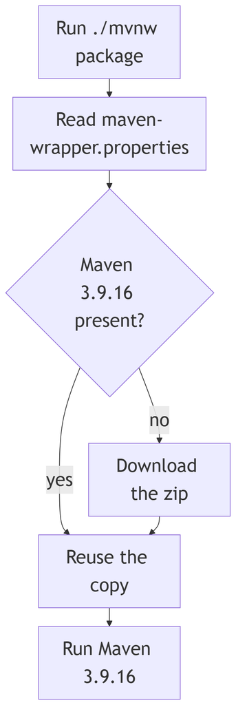

*Figure 6.1 — How the Maven wrapper finds the exact Maven version*

*Text description:* A decision flow read from top to bottom. Running `./mvnw package` makes the script read the file `.mvn/wrapper/maven-wrapper.properties` and ask whether Maven 3.9.16 is already downloaded. If not, it downloads the zip named by `distributionUrl` in that file. In both cases it then reuses that copy to run Maven with your arguments.

Only the first run pays for the download. Every later run, on your laptop, in the Docker build or in CI, ends at the same last box, which is the point of the wrapper.

The wrapper arrived late. In the first review of the project, the AI technical-manager reviewer (an AI review agent, like the other reviewer you will meet) listed the missing Dockerfile, CI and Maven wrapper as one finding. The wrapper was added in the commit that moved the project to Java 25, the one behind milestone `book-m5-platform`.

This has a practical consequence for you. At the tags `book-m0-mvp` to `book-m4-reading` there is no `mvnw`, and the project builds with Spring Boot 3.3.4 on Java 21. To run one of those milestones you need a JDK 21 and a Maven that you install yourself (Maven 3.9 is the line the wrapper later pinned), and you start the app with `mvn` instead of `./mvnw`. Table IV.3 in Part IV lists exactly what each group of tags needs. Reading the older code with `git show <tag>:<path>` (Chapter 7) needs none of that.

### 6.8 Lifecycle: compile, test, package, verify

Maven runs a fixed sequence of **phases**, and asking for a phase runs it and every phase before it. That is why `./mvnw package` also compiles and tests: those phases come earlier in the sequence. Table 6.2 lists the ones you will use.

Table 6.2 — Maven phases you will use

[output not shown]

Figure 6.2 draws the same phases as a chain, with what each one does in this project.

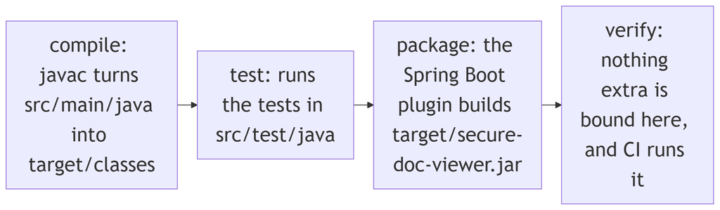

*Figure 6.2 — The Maven phases and what each does in this project*

*Text description:* Four boxes in a row, read left to right: compile, test, package, and verify. Each box says what the phase does here: compiling source into classes, running the tests, building the executable JAR, and finally verify, which adds nothing extra in this project and is the phase continuous integration runs. Notice that a phase on the left must succeed before one on the right runs.

Asking for a phase runs everything to its left. A failing test in the second box stops the chain, so no JAR is produced from broken code.

Two practical flags appear in the project's scripts. `-DskipTests` (a `-D` sets a property) tells Maven to compile the tests but not run them; the Dockerfile uses it, because the container build only needs the JAR. `-B` means batch mode: no colors and no interactive prompts, which suits automated runs. `-q` means quiet, printing only errors.

Now build the whole thing and run it. The first command runs every test, so it takes longer than `compile`. Expect a minute or two on a laptop, with many lines printed while it works. A long quiet stretch is normal; a hang is when nothing changes for ten minutes. The test that needs Docker (Section 6.5) is skipped if Docker is not running:

```bash
./mvnw package
```

You should see the test runner report how many tests ran, in lines such as `Tests run: 114, Failures: 0`, then `BUILD SUCCESS`. A test that fails stops the build before the JAR is created, which is the point: a broken change cannot be packaged by accident. To skip the tests when you only need the JAR:

```bash
./mvnw package -DskipTests
```

Then start the application from the JAR:

```bash
java -jar target/secure-doc-viewer.jar
```

`java -jar` runs the executable JAR from Section 6.6. The app needs its settings and a database first (Chapters 2, 9 and 10), so at this point it stops with an error about missing configuration. That is the app doing its job: for example, it refuses to start without a signing secret of at least 32 characters (Chapter 13 explains that check).

### 6.9 Convention over configuration, and the alternatives

Maven relies on **convention over configuration**: if you put files where it expects them, it needs no instructions. Java code goes in `src/main/java`, tests in `src/test/java`, and Maven knows how to compile both without a single line of setup. That is why the `pom.xml` in this project is short even though the build does a lot.

Maven is not the only Java build tool. **Gradle** describes the build in a script written in a programming language instead of XML, which gives more flexibility and can be faster on large projects. The price is that every build file can differ from the next, where every Maven project follows the same shape. This book uses Maven because the project does; the project's history records no comparison of build tools, so this book does not invent a reason. What you learn transfers: dependencies, scopes, phases, and layout have direct counterparts in Gradle.

### 6.10 Common mistakes

Build failures look alarming and are usually one of a few causes. Read the first `ERROR` line; the lines after it are often echoes of the same problem.

**"release version 25 not supported."** The compiler is older than Java 25. The `<java.version>25</java.version>` property asks for Java 25, and an older JDK refuses. Check `java -version` and, if needed, install a JDK 25 and make sure it is the first one found (Chapter 2's `PATH` and `JAVA_HOME`).

**"The JAVA_HOME environment variable is not defined correctly."** Maven found a Java installation it cannot use. Point `JAVA_HOME` at the JDK folder, or unset it if it points to a folder that no longer exists.

**`Permission denied` when you run `./mvnw` on macOS or Linux.** The script lost its execute permission, for example after being copied through a system that dropped it. Fix it with `chmod +x mvnw`. The project's own Dockerfile does exactly this before building (`RUN chmod +x mvnw && ...`), for the same reason.

**A strange error mentioning `\r` or "bad interpreter."** The script's line endings were converted to the Windows style (Chapter 2 introduced line endings), which the Unix shell cannot read. Re-clone with Git's default settings, or ask your editor to save `mvnw` with Unix line endings.

**Downloads fail or stall.** Maven needs the internet the first time. A firewall or an offline machine stops it. Once the cache is filled, you can work offline; the project's Dockerfile runs `dependency:go-offline` to fill the cache in a separate step (Section 6.11).

**A build works, then behaves oddly after you switch versions.** Old compiled files remain in `target`. Run `./mvnw clean package` to start from nothing.

## Advanced tier: The shape of the project

*On a first read you can skip to "In this project"; Chapter 36 returns to supply-chain checks.*

### 6.11 Pinning, reproducibility, and the supply chain

Everything in this chapter serves one goal: **a reproducible build**, where the same source code produces the same result on any machine and on any day. The project pins versions at every layer:

- Spring Boot's version, through the `<parent>`;
- the libraries the parent does not manage, through properties such as `pdfbox.version`;
- Maven itself, through the wrapper;
- and, in Chapter 10, the Docker images, by digest.

Pinning matters for security as well as convenience. The libraries you depend on are your **supply chain**: code written by others, running with your app's privileges. A flaw in one of them is a flaw in your app. The project treats this as ordinary work, not an emergency, and it has real examples.

#### The Tomcat pin

**Listing 6.7 — `ci.yml` (book-m6-final, excerpt: job `dependency-scan`)**

```yaml
  dependency-scan:
    name: Known-vulnerability scan (OSV)
    runs-on: ubuntu-latest
    steps:
      - uses: actions/checkout@3d3c42e5aac5ba805825da76410c181273ba90b1  # v7.0.1
      # Fails the build if any Maven or npm dependency (including transitive
      # ones) has a published vulnerability.
      - run: >
          docker run --rm -v "$PWD:/src:ro" ghcr.io/google/osv-scanner:v2@sha256:afd838850ac1a0fcc15ff4a041dc9ba11123c3f0d2666217a5f0fcf9222b55fa
          scan source --lockfile=/src/pom.xml --lockfile=/src/frontend/package-lock.json
```

*Path: `.github/workflows/ci.yml`*

The job runs a scanner against `pom.xml` and the frontend's lock file, and fails the build if any dependency, direct or transitive, has a published vulnerability. Notice the long `sha256:` strings: they pin the scanner and even the checkout step to exact versions, for the same reason the wrapper pins Maven. Chapter 36 walks through the full workflow.

#### Caching downloads in a container

A build in a fresh Docker container has an empty cache, so it downloads everything each time, unless the Dockerfile is arranged well. The project's backend Dockerfile copies `pom.xml` first, downloads all dependencies in one step, and only then copies the source code. Because Docker reuses a step whose inputs have not changed, the slow download is repeated only when `pom.xml` changes. Chapter 10 explains the mechanism.

### 6.12 The same project at two milestones

Comparing the `pom.xml` at the first and last milestones shows how a project grows. At `book-m0-mvp` the file was small: Spring Boot 3.3.4 as parent, `java.version` 21, and only three dependencies.

**Listing 6.8 — `pom.xml` (book-m0-mvp, excerpt: properties and dependencies)**

```xml
    <properties>
        <java.version>21</java.version>
        <pdfbox.version>3.0.3</pdfbox.version>
    </properties>

    <dependencies>
        <dependency>
            <groupId>org.springframework.boot</groupId>
            <artifactId>spring-boot-starter-web</artifactId>
        </dependency>

        <dependency>
            <groupId>org.apache.pdfbox</groupId>
            <artifactId>pdfbox</artifactId>
            <version>${pdfbox.version}</version>
        </dependency>

        <dependency>
            <groupId>org.springframework.boot</groupId>
            <artifactId>spring-boot-starter-test</artifactId>
            <scope>test</scope>
        </dependency>
    </dependencies>
```

*Path: `pom.xml`*

Web serving, PDF reading, and tests: that is the whole first version. Milestone by milestone, the file gained security, validation, JPA (the Java Persistence API, which stores objects in a database), Flyway, the MySQL driver, and monitoring. The versions changed once, at `book-m5-platform`: Spring Boot 3.3.4 to 4.1.1, Java 21 to 25, and PDFBox 3.0.3 to 3.0.8, all in one move. The reason on record is that the threat-modeling review had flagged Spring Boot 3.3 as past its open-source support and PDFBox as behind, and the implementer chose the latest generally available versions checked on Maven Central. Note that the starter's name changed as well, from `spring-boot-starter-web` to `spring-boot-starter-webmvc`, which is the Spring Boot 4 split you read about in Listing 6.3. Chapter 30 tells the whole upgrade.

### 6.13 Directory layout

Table 6.3 shows the layout at `book-m6-final`, which follows Maven's conventions.

*Pattern note: A single deployable with clear package boundaries is a modular monolith (Chapter 39, Section 39.6).*

Table 6.3 — Where things live

| Path | Holds |
| --- | --- |
| `pom.xml` | The build description |
| `mvnw`, `mvnw.cmd`, `.mvn/wrapper/` | The wrapper scripts and the pinned Maven version |
| `src/main/java/` | The application's Java code, in folders that match packages |
| `src/main/resources/` | Non-code files the app reads: `application.yml`, the database migrations in `db/migration/` |
| `src/test/java/` | Tests |
| `src/test/resources/` | Settings for tests (`application-test.yml`) |
| `target/` | Build output (ignored by Git) |
| `frontend/` | The Angular application (Part III) |
| `Dockerfile`, `docker-compose.yml` | Packaging (Chapter 10) |

Splitting `src/main` from `src/test` matters. Test code and test libraries never enter the packaged application, so the JAR carries nothing that exists only to check it. Files under `src/main/resources` are copied into the JAR untouched, which is how `application.yml` and the SQL migrations travel with the program. Chapter 18 covers the tests themselves, and Chapter 9 explains the migration files.

The Java folders repeat the packages of Chapter 4. A class in the package `com.example.securedocviewer.document` lives in `src/main/java/com/example/securedocviewer/document/`. The same class's test lives at the same path under `src/test/java`, which makes tests quick to find.

## In this project

- `pom.xml`, `mvnw`, `mvnw.cmd` and `.mvn/wrapper/maven-wrapper.properties`: the build.
- `Dockerfile`: runs `./mvnw -B -q -DskipTests package` to build the JAR inside a container, and copies the dependency list first so downloads stay cached until `pom.xml` changes. - `.github/workflows/ci.yml`: runs `./mvnw -B verify` on every pull request, plus the dependency scan from Listing 6.7.
- `.github/dependabot.yml`: a bot that proposes dependency updates weekly (Chapter 36). - Milestones: the wrapper and the Java 25 upgrade arrive at `book-m5-platform`; earlier tags build with Java 21 and Spring Boot 3.3.4.

## Try it

### Exercise 6.1 ★ Read the coordinates

Open `pom.xml` at `book-m6-final`. What are the project's `groupId`, `artifactId`, and version? Which Java version does it compile for?

*Solution:* Appendix C, Exercise 6.1.

### Exercise 6.2 ★ Build it

With Java 25 installed and the project cloned, run `./mvnw compile`, then `./mvnw package -DskipTests`. Where does the JAR appear, and what is inside `target/classes`?

*Solution:* Appendix C, Exercise 6.2.

### Exercise 6.3 ★★ Why pin Tomcat?

*Solution:* Appendix C, Exercise 6.3.

### Exercise 6.4 ★★ Follow the tree

Run `./mvnw dependency:tree`. Find `pdfbox` in the output and list two libraries that appear indented beneath it or nearby. Then explain, in two sentences, why you did not have to list them in `pom.xml`.

*Solution:* Appendix C, Exercise 6.4.

### Exercise 6.5 ★★★ Compare two milestones

Print the `pom.xml` at `book-m0-mvp` and at `book-m2-documents` with `git show <tag>:pom.xml`. List every dependency added between them and, for each, say which feature of the app you think needed it. Which ones have a scope other than the default?

*Solution:* Appendix C, Exercise 6.5.